BVDOutbreakSize

Appearance

# Estimating the current size of the 2026 DRC Bundibugyo virus outbreak: a joint Bayesian re-analysis of the McCabe et al. report

**Authors:** Sam Abbott, Kath Sherratt, Samuel Brand and Sebastian Funk.

> **⚠️ Final release of this model formulation.** The joint fit now implies a larger outbreak than any single data stream does on its own ([#212](https://github.com/epiforecasts/BVDOutbreakSize/issues/212)) and is being replaced by a simpler discrete-time renewal model, so treat the estimates here as provisional.

**Last updated:** 5 June 2026. This is a live report, re-run as new data arrive, so the estimates change between updates.

**Abstract.** An outbreak of Ebola disease caused by Bundibugyo virus (BVD) is ongoing in the Democratic Republic of the Congo (DRC), with cases also detected across the border in Uganda. Estimating the likely current size of the outbreak is useful for the response, but most cases are not yet reported and have to be inferred from the data streams that are available. The Imperial College London report (McCabe et al., [18 May 2026](https://www.imperial.ac.uk/mrc-global-infectious-disease-analysis/research-themes/preparedness-and-response-to-emerging-threats/report-ebola-18-05-2026/), revised in a [20 May 2026 update](https://www.imperial.ac.uk/media/imperial-college/medicine/mrc-gida/Report-ebola-update-20-05-2026.pdf)) estimates the size with two analyses, geographic spread from the cases exported to Uganda and back-calculation from suspected deaths in DRC. Building on that work, we re-analyse the same problem as a single joint Bayesian model over the latent cumulative infection count, fitting all streams together with priors on the nuisance parameters that the report varies in scenario sweeps. Infections are the root of the generative process; symptom onsets follow after a sampled incubation period, and every observed stream sits downstream of those onsets through its own reporting delay. Beyond the exported cases and DRC deaths the report uses, we condition on two further streams, the reported cases in DRC (with an ascertainment component) and the deaths among exported cases in Uganda. We fit the DRC streams to the full situation-report trajectory, conditioning on the between-vintage increments across successive sitreps rather than only the latest cumulative total, which sharpens the growth rate. We also add a no-onward-transmission projected-deaths counterfactual, a one-week-ahead forecast and an onset-to-death delay sensitivity analysis, and replace two closed-form approximations (the deaths convolution and the small-growth-rate exports term) with their exact forms. We report the joint posterior over the cumulative case count from current data; to separate the effect of newer data from the change in method we also fit the model to the data as of each report version in sequence (18 May, then the 20 May update), comparing against both a joint reimplementation of the report's approach and its original published estimates at each version. We report the cumulative infection count as the headline quantity, with the cumulative case count recovered downstream through the incubation period for comparison with the report.

**Scope.** This work is motivated by adding an external view of the current situation, based on our understanding of real-time infectious disease dynamics and the infection process that gives rise to observed epidemic surveillance counts. We are actively developing it and encourage feedback, so please get in touch. We fully support reuse and adaptation. Find out more in the contributing guide.

**Use of AI.** The model code and analysis were drafted by a language model and reviewed and revised under human oversight; the named authors are responsible for that oversight.

**Why our numbers differ from McCabe et al.** Two reasons. First, the method: we fit all streams jointly in a single Bayesian model rather than combining separate scenario analyses (see each way our method departs from the report). Second, the data: our cut-off is later than either McCabe et al. report version (16 May for the 18 May report; 18 May for the 20 May update), and we fit the DRC streams to the full run of situation reports rather than a single total at the cut-off, so the growth rate is informed by the shape of the reported trajectory rather than the prior alone. The joint posterior assumes a single common cut-off for every data stream, so the deaths, exports and reported-case counts must all be kept in sync to the same date.

This page is generated from [`docs/examples/analysis.jl`](https://github.com/epiforecasts/BVDOutbreakSize/blob/main/docs/examples/analysis.jl); the model code it calls is in [`src/`](https://github.com/epiforecasts/BVDOutbreakSize/tree/main/src). See the *LLM-driven reimplementation* limitation below for the oversight context behind the Use of AI note.

**Offline copy.** A self-contained single-file HTML version of this report, built from the same run, is attached to each results release: [download the latest](https://github.com/epiforecasts/BVDOutbreakSize/releases/latest/download/analysis.html).

**See:** current outbreak size · comparison with McCabe et al. · how the data streams compare · limitations.

## What we do differently from McCabe et al.

We reimplement the McCabe et al. (McCabe and others, May 2026) report as a single Bayesian model fitted jointly to every data stream. The points below summarise how it differs from the report; the Methods section carries the full treatment and the limitations are listed separately.

**Expand: differences from the report**

**Latent process and parameters**

- *Infections as the latent quantity.* We model the cumulative infection count and map it through an incubation period to onsets and reported cases, recovering the case count McCabe et al. estimate for comparison.
- *Joint posterior, not 15 scenario estimates.* The growth rate, case fatality ratio (CFR), delays, traveller volume and surveillance dispersion are given priors and sampled jointly, where McCabe et al. fix each and sweep scenarios.
- *Growth prior centred on the molecular clock.* The growth-rate prior is centred on the 20-day doubling time from the phylodynamic reanalysis of the first ten BDBV genomes (Cuomo-Dannenburg and Ghafari, 2026), rather than McCabe et al.'s 14-day central scenario. The McCabe et al. Method 2 reproduction pins the growth rate to their 14-day value, so that comparison is on their own assumptions.

**Delays and convolutions**

- *Explicit infection→detection delay for exports.* Exports follow a delay convolution of the infection trajectory rather than a fixed detection window, capturing pre-symptomatic travel. The window form is kept for the comparison.
- *Exact deaths convolution.* We evaluate the onset-to-death convolution in exact closed form, where McCabe et al. use a large-time approximation.

**Likelihoods and data streams**

- *Over-dispersed likelihoods.* Deaths and reported cases use a negative-binomial likelihood with a shared surveillance dispersion, where McCabe et al. use Poisson for the deaths and do not model the reported cases.
- *Ascertainment extension.* A reporting-fraction hyperprior gives a joint posterior over the reported suspected-case count alongside the deaths and exports.
- *Suspected, confirmed and samples-received streams.* Three streams absent from McCabe et al., tying the reported counts and the laboratory pipeline to the same latent outbreak.
- *Per-vintage fit of the DRC streams.* The suspected and confirmed series are fitted across successive situation reports rather than as single totals, so the growth rate is informed by the reported trajectory.

**Extensions**

- *No-onward-transmission counterfactual.* A lower bound on the eventual death toll if all onward transmission stopped at the cut-off, and the committed counterfactual-year totals for infections, BVD deaths, confirmed cases and confirmed deaths.
- *Posterior-predictive forecasts.* A one-week-ahead projection of the four trusted quantities (infections, true BVD deaths, confirmed cases and confirmed deaths).

## Limitations

The limitations are grouped by the data, the model assumptions and design, and the implementation, with the most consequential first in each group.

**Expand: limitations**

**Data and what it can support**

**Model assumptions and design**

**Implementation**

- *LLM-driven reimplementation.* The model code, priors, convolution implementation and analysis were drafted by a language model from the published McCabe et al. (McCabe and others, May 2026) report and the companion delay reanalysis, then reviewed and revised. Not independently replicated against the authors' code.
- *First-vintage positivity peak.* The model slightly under-shoots the first vintage's positivity peak.

**Load packages and seed the RNG**

julia

```julia
using Turing
using Turing: to_submodel, @varname
using Distributions
using StatsFuns: logit, logistic
using DataFrames: DataFrame, rename
import CSV
using Random
using Markdown
using Dates: Date, Day, value
using BVDOutbreakSize
using BVDOutbreakSize: integrate_cumulative,
                       integrate_exports_deaths, delay_convolution
import CairoMakie

# Render figures at higher resolution so they stay crisp in the docs.
CairoMakie.activate!(type = "png", px_per_unit = 3)

Random.seed!(20260518)

# Opt-in TensorBoard tracing of the model fits: set the `BVD_TRACE_DIR`
# environment variable to a directory and every fit below streams its
# draws (warmup included) to a per-fit run under it. Off by default, so
# normal builds are unchanged. Inspect with `tensorboard --logdir <dir>`.
# Loading TensorBoardLogger activates the package's tracing extension.
haskey(ENV, "BVD_TRACE_DIR") && @eval using TensorBoardLogger
function trace_kw(label)
    # A relaxed target-acceptance (δ = 0.9) keeps the docs build within
    # the CI time budget. Larger NUTS steps mean a handful of
    # divergences in the joint fit's geometry are accepted and expected;
    # R-hat on the headline parameters stays ≈ 1.0. Two longer chains
    # (set via the `nuts_sample` defaults) halve the per-chain warmup and
    # compile cost relative to four shorter ones.
    base = (; target_accept = 0.9)
    haskey(ENV, "BVD_TRACE_DIR") ?
    (; base..., callback = tensorboard_callback(
            joinpath(ENV["BVD_TRACE_DIR"], label)),
        warmup = true) : base
end
```

```
trace_kw (generic function with 1 method)
```

## Methods

### Data

The analysis uses a handful of aggregate counts. The DRC suspected cases, suspected deaths and laboratory-confirmed cases are the national cumulative totals from the INSP situation reports (Institut National de Santé Publique and Centre des Opérations d'Urgence de Santé Publique (COUSP-RDC), May 2026), read from the report PDFs (archived by INRB-UMIE (INRB-UMIE, 2026)). We draw straight from the sitreps rather than the published per-zone CSVs because the regional (health zone) breakdown is inconsistent with the national totals: the zone sums omit cases not yet attributed to a zone, understating the count. The figures were read from the PDFs with an LLM agent and independently re-scanned by a second agent; the values, with their per-vintage sources and caveats, are recorded in `data/insp_sitrep_scanned.csv` and `data/observations.toml`. The 18-22 May points predate that reporting format and use WHO AFRO Weekly External Situation Report 01 (World Health Organization Regional Office for Africa, May 2026). The Uganda export-case counts and deaths, the first-export detection date and the dated export death come from WHO Disease Outbreak News DON602 (World Health Organization, May 2026); the cross-border traveller volume and source population from the McCabe et al. report (McCabe and others, May 2026). The first table lists each figure as of the cut-off (the suspected counts are unconfirmed); the source population is fixed and the traveller volume is given a normal prior around the McCabe et al. figure. The three DRC streams are additionally resolved by sitrep vintage and fitted as between-vintage increments, shown in the second table.

**Loading observations and building the data table**

julia

```julia
obs = load_observations()
observations_table = DataFrame(
    field = [
        "exported_cases",
        "exports_deaths",
        "total_deaths",
        "reported_cases",
        "daily_outbound_travellers",
        "daily_outbound_travellers_sd",
        "source_population"
    ],
    value = [
        obs.exported_cases,
        obs.exports_deaths,
        obs.total_deaths,
        obs.reported_cases,
        obs.daily_outbound_travellers,
        obs.daily_outbound_travellers_sd,
        obs.source_population
    ],
    source = [
        obs.sources.exported_cases,
        obs.sources.exports_deaths,
        obs.sources.total_deaths,
        obs.sources.reported_cases,
        obs.sources.daily_outbound_travellers,
        obs.sources.daily_outbound_travellers_sd,
        obs.sources.source_population
    ]
);

const ITURI_POPULATION = obs.source_population
const ITURI_DAILY_TRAVEL = obs.daily_outbound_travellers
const EXPORTED_CASES = obs.exported_cases
const EXPORTS_DEATHS = obs.exports_deaths
```

```
1
```

7×3 DataFrame

| Row | field String | value Float64 | source String |
| --- | --- | --- | --- |
| 1 | exported_cases | 3.0 | WHO DON 2026-DON602, 2026-DON603, and WHO Director-General Ministerial Briefing 25 May 2026 — three travel-related (DRC) cases imported into Uganda: (i) elderly man admitted Kampala 11 May 2026, died … |
| 2 | exports_deaths | 1.0 | WHO DON 2026-DON602 — one death (import #1, died 14 May 2026). No deaths reported among imports #2 or #3 as of the 28 May 2026 cut-off. The exports count is the cumulative detected by the cut-off: a 4… |
| 3 | total_deaths | 246.0 | INSP SitRep 012 revised re-issue (SitRep_MVE_012-2026_v2, data as of 26 May 2026), front-page `Cumul Décès suspects`, read from the situation-report PDF. National cumulative suspected deaths; the revi… |
| 4 | reported_cases | 1077.0 | INSP SitRep 012 (data as of 26 May 2026), front-page `Cumul cas suspects`, read from the situation-report PDF. National cumulative suspected cases; recorded in data/insp_sitrep_scanned.csv. This repor… |
| 5 | daily_outbound_travellers | 1871.0 | McCabe et al. Table 3 — mean daily PoE flow across seven Uganda-DRC border points, Ituri side |
| 6 | daily_outbound_travellers_sd | 200.0 | PoE-to-PoE variation and sitrep sampling uncertainty; ~10% CV |
| 7 | source_population | 4.3922e6 | McCabe et al. Table 1 — Ituri Province population |

**Building the per-vintage time-series table**

julia

```julia
# Align every stream on the confirmed-case dates (the longest history,
# running to the cut-off) and pad with `missing` where a frozen
# suspected stream has no vintage for that date.
_align(h, dates) = map(
    d -> begin
        i = findfirst(==(d), h.dates)
        i === nothing ? missing : h.values[i]
    end, dates)
vintage_dates = obs.confirmed_case_history.dates
vintage_table = DataFrame(
    sitrep_date = vintage_dates,
    suspected_cases = _align(obs.reported_case_history, vintage_dates),
    confirmed_cases = obs.confirmed_case_history.values,
    suspected_deaths = _align(obs.death_history, vintage_dates),
    confirmed_deaths = _align(obs.confirmed_death_history, vintage_dates)
);
```

21×5 DataFrame

| Row | sitrep_date String | suspected_cases Int64? | confirmed_cases Int64 | suspected_deaths Int64? | confirmed_deaths Int64? |
| --- | --- | --- | --- | --- | --- |
| 1 | 2026-05-18 | 516 | 33 | 131 | missing |
| 2 | 2026-05-19 | 575 | 51 | 148 | missing |
| 3 | 2026-05-20 | 672 | 57 | 160 | missing |
| 4 | 2026-05-21 | 745 | 79 | 175 | missing |
| 5 | 2026-05-22 | 872 | 83 | 204 | missing |
| 6 | 2026-05-23 | 904 | 101 | 220 | missing |
| 7 | 2026-05-24 | 906 | 105 | 223 | missing |
| 8 | 2026-05-25 | 998 | 106 | 238 | missing |
| 9 | 2026-05-26 | 1077 | 121 | 246 | 17 |
| 10 | 2026-05-27 | missing | 125 | missing | 17 |
| 11 | 2026-05-28 | missing | 210 | missing | 17 |
| 12 | 2026-05-29 | missing | 263 | missing | 42 |
| 13 | 2026-05-30 | missing | 282 | missing | 42 |
| 14 | 2026-05-31 | missing | 321 | missing | 48 |
| 15 | 2026-06-01 | missing | 344 | missing | 60 |
| 16 | 2026-06-02 | missing | 363 | missing | 62 |
| 17 | 2026-06-03 | missing | 381 | missing | 64 |
| 18 | 2026-06-04 | missing | 452 | missing | 82 |
| 19 | 2026-06-05 | missing | 488 | missing | 86 |
| 20 | 2026-06-06 | missing | 515 | missing | 91 |
| 21 | 2026-06-07 | missing | 550 | missing | 101 |

### Model

#### Model overview

We model a single outbreak seeded by one zoonotic introduction that then grows exponentially, so the cumulative number of people ever infected by outbreak age is , set by a growth rate (equivalently a doubling time). We never observe infections directly. Instead each available data stream observes a thinned, delayed or transformed view of that same latent incidence curve. Reported cases in the DRC are an ascertained fraction of the cumulative cases. Suspected deaths in the DRC are the case fatality ratio applied to past incidence, convolved with the onset-to-death delay. Cases exported to Uganda are the fraction of recent cases that crossed the border, set by the travel rate and a detection window. Deaths among the exported cases are those cases weighted by their probability of having died by now.

Fitting all four streams together gives the posterior for the latent cumulative infection count at the report date — the quantity we care about — while sharing the growth, delay, fatality and ascertainment parameters across the streams that depend on them.

In implementation terms, the model is assembled from small reusable Turing (Ge *et al.*, 2018) submodels of three kinds, defined in the order they appear below: building-block submodels, observation submodels and composers.

The table below shows which building-block parameters feed each observation submodel. The *confirmed & received* column covers the laboratory pipeline, which observes the confirmed (PCR-positive) cases and the samples received from the suspect pool:

| Parameter | Exports | Deaths | Cases | Confirmed & received | Export deaths (time-resolved) | First export-detection timing | Genetic seeding |
| --- | --- | --- | --- | --- | --- | --- | --- |
| Growth | ● | ● | ● | ● | ● | ● | ● |
| Incubation period | ● | ● | ● | ● | ● | ● |  |
| Onset-to-death delay |  | ● |  |  | ● |  |  |
| Case-fatality ratio |  | ● |  |  | ● |  |  |
| Onset-to-report delay | ● |  | ● | ● | ● | ● |  |
| Report-to-lab delay |  |  |  | ● |  |  |  |
| PCR sensitivity |  |  |  | ● |  |  |  |
| PCR specificity |  |  |  | ● |  |  |  |
| Severity enrichment |  |  |  | ● |  |  |  |
| Lab capacity / receipt delay |  |  |  | ● |  |  |  |
| Background rate |  |  | ● | ● |  |  |  |
| Surveillance dispersion |  | ● | ● | ● |  |  |  |
| Ascertainment | ● |  | ● | ● | ● | ● |  |
| Traveller volume | ● |  |  |  | ● | ● |  |

The model components, in the order they appear below:

1. **Building-block submodels** — one per parameter family, listed in the table above. Each samples its own priors and returns a small NamedTuple of values, introducing only the maths for its own parameters.
2. **Observation submodels** — exports, deaths, cases, the laboratory pipeline (confirmed cases and samples received), deaths-among-exports (time-resolved), and the first export-detection timing. Each takes the growth state as input, introduces the forward integral it needs and the likelihood, and ties one data stream to the latent .
3. **Composers** — one per analysis: the five single-stream fits, a two-stream reimplementation of the report's methods (exports and deaths), and the full joint fit. Each samples the building blocks and the relevant observation submodels. A composer conditionally includes only the likelihoods for the streams it uses, so a single-stream fit never instantiates the other observation submodels.

Beyond the model itself:

#### Building-block submodels

Each building-block submodel introduces only the mathematical objects and priors for one parameter family; the likelihoods and forward integrals enter later, in the observation submodels that use them.

The implementation approach taken here is based on the hantavirus modelling project (Funk and Abbott, 2026): Mooncake (Tebbutt and Ge, 2024) automatic differentiation, the Integrals (SciML contributors, 2024) quadrature helpers, a NaN-safe NegBinomial, FlexiChains, and PairPlots (Thompson, 2024) with AlgebraOfGraphics (Danisch and Krumbiegel, 2021) for the figures.

##### Growth — exponential

The outbreak is seeded days ago by a single zoonotic case and grows exponentially with doubling time , giving the cumulative- incidence trajectory

so that the cumulative infection count at the cut-off is with the number of doublings since seeding. The doubling time is the primary epidemiological assumption; each choice of doubling time implies a growth rate , and we place the prior on that implied growth rate directly. The centre comes from the molecular-clock estimate for this outbreak: the phylodynamic reanalysis of the first ten BDBV genomes by (Cuomo-Dannenburg and Ghafari, 2026) reports a mean doubling time of 15.2-24.5 days across six substitution-rate assumptions, so we centre on 20 d (the middle of that range, slower than McCabe et al.'s 14-day central scenario) with a log-SD of 0.15:

Because is a reciprocal, putting this LogNormal on is exactly equivalent to a prior on the doubling time: a reciprocal negates and shifts the log-scale mean but preserves the log-scale SD 0.15, so the implied doubling-time prior is the same on , as is every derived quantity. Only the sampled coordinate differs. The log-SD is set by reading the 15.2-24.5 day spread of their mean doubling times as roughly a 95% interval, which implies a log-SD near 0.12; 0.15 inflates that a little to allow for their wide per-assumption intervals without drifting off the molecular-clock estimate. The implied 95% doubling-time interval is then roughly d, sitting on the reported range. The McCabe et al. Method 2 reproduction below instead pins the growth rate to their 14-day central doubling time, so that comparison rests on McCabe et al.'s own assumptions rather than the genetic update. The fit stays likelihood-dominated, so the situation-report trajectory drives the posterior growth rate.

Rather than sampling directly (ridge-correlated with through ), the model samples the *doubling count* . Then is near-orthogonal to . We give a truncated-Normal prior with SD 3, centred on a base assumption that advances with the cut-off date:

The base assumption is McCabe et al.'s first report (18 May 2026): its Method 2 central scenario of 501 cases is a doubling count . Each day that the cut-off runs past that report adds a fraction of a doubling at the central 20-day doubling time (the (Cuomo-Dannenburg and Ghafari, 2026) molecular-clock estimate, shared with the growth-rate prior above), so the size prior stays centred on the plausible outbreak as the data are refreshed rather than being fixed at the report-date value. The doubling time , the elapsed time and are exposed as deterministics so they appear in posterior tables and pair plots.

**Submodel: exponential_growth_model**

julia

```julia
@model function exponential_growth_model(;
        r_prior = LogNormal(log(log(2) / M_PRIOR_DOUBLING_DAYS), 0.15),
        m_prior = truncated(Normal(M_PRIOR_BASE, 3.0); lower = 0))
    r ~ r_prior
    m ~ m_prior
    τ := log(2) / r
    T := m * τ
    C_T := 2.0 ^ m
    cumulative = s -> exp(r * s)
    return (; τ, r, m, T, C_T, cumulative)
end
```

##### Incubation period

The growth trajectory above counts *infections*. People are only seen once they develop symptoms, so the onsets that drive every observed stream are the infections shifted forward by the incubation period. Treating the trajectory as onsets directly would date the outbreak wrongly and understate how many people are already infected. We therefore sample the incubation period as a delay, like every other delay in the model, and convolve it with the infection trajectory to get onsets; the per-stream reporting delays then act on those onsets.

The incubation period cannot be fitted from the BDBV line list, which has no exposure dates (Funk and Abbott, 2026), so we take the Bundibugyo estimate from the 2007 Uganda outbreak: a mean of 6.3 days, 95% CI 5.2-7.3 (MacNeil *et al.*, 2010). We put the prior on the mean and the coefficient of variation so MacNeil et al.'s reported uncertainty on the mean is carried through directly, and recover the gamma shape and scale from them. MacNeil et al. give no interval on the spread, so the coefficient of variation has a weakly-informative prior chosen to keep individual incubation times within their observed 2-20 day range.

**Submodel: incubation_model**

julia

```julia
@model function incubation_model(;
        mean_prior = truncated(Normal(6.3, 0.54); lower = 0.1),
        cv_prior = truncated(Normal(0.55, 0.12); lower = 0.1))
    mean_inc ~ mean_prior
    cv_inc ~ cv_prior
    α_inc := inv(cv_inc^2)
    θ_inc := mean_inc * cv_inc^2
    return (; α = α_inc, θ = θ_inc, mean = mean_inc, cv = cv_inc,
        dist = Gamma(α_inc, θ_inc))
end
```

##### Genetic seeding bound

A BEAST time tree of the first ten sequenced genomes (Amuri-Aziza *et al.*, 2026) places the TMRCA, the age of the oldest internal node of the tree, at a mean of 25 March 2026, with a 95% HPD interval of about days. The temporal sampling range is too short to estimate the clock, so it is fixed. The source analysis considers two literature rates for the 2013–2016 West African Ebola epidemic (Holmes *et al.*, 2016): a substitutions/site/year rate across all public data, and a faster early-epidemic rate that dates the TMRCA more recently. We use the rate in the main analysis and the rate in the clock-rate sensitivity. This is a lower bound on the seeding time . Adding sequences, or more geographically representative ones, can only push the TMRCA earlier, never later, as the sampled tree is almost entirely from Bunia. Combining the genetic TMRCA with the other data streams as a seeding bound follows a suggestion of N. Ferguson (Ferguson, 2026). We parameterise the bound as an uncertain threshold , where is the data cut-off date minus the reported TMRCA date, so it tracks the cut-off rather than a fixed offset. We require , leaving free above it. Marginalising over gives a soft one-sided likelihood,

**Submodel: genetic_seeding_model**

julia

```julia
@model function genetic_seeding_model(T, tmrca_days::Real;
        tmrca_days_sd::Real)
    ## The molecular-clock TMRCA is a right-censored, noisy reading of the
    ## true seeding time T: deeper or wider sampling only pushes it older,
    ## so we learn the reading is at least `tmrca_days`, i.e. P(read ≥ g).
    tmrca_days ~ censored(Normal(T, tmrca_days_sd); upper = tmrca_days)
    return (; tmrca_days, tmrca_days_sd)
end
```

Observing at the upper censoring point of contributes the log probability of the censored upper tail, which is the soft bound of Eq. (3a):

##### Onset-to-death delay

Following McCabe et al., we assume the symptom-onset-to-death delay is gamma distributed with shape and scale , with density and CDF :

The McCabe et al. report uses the point estimate of (Rosello and others, 2015). We instead use the companion Bayesian reanalysis of the same Isiro line list (Funk and Abbott, 2026), which re-estimates the delay with uncertainty. The two prior means are that reanalysis' posterior estimates of the gamma shape and scale, and the two standard deviations are set so each prior reproduces the reanalysis' 95% credible interval on that parameter. The published uncertainty therefore enters the fit directly rather than collapsing onto a single point estimate:

This implies a prior mean onset-to-death delay of days. The delay estimation in that reanalysis follows the recommendations of (Charniga *et al.*, 2024).

**Submodel: delay_model**

julia

```julia
@model function delay_model(;
        alpha_prior = truncated(Normal(4.3, 1.22); lower = 0),
        theta_prior = truncated(Normal(2.6, 0.82); lower = 0))
    α ~ alpha_prior
    θ ~ theta_prior
    return (; α, θ, dist = Gamma(α, θ))
end
```

##### Onset-to-report delay

Suspected and laboratory-confirmed counts see the growth curve through one delay: an onset-to-report delay from symptom onset to the case appearing on the suspected line list. The laboratory pipeline reads from the same reported backlog rather than adding a second delay; the lab selects which received samples to run, as in the confirmed-case likelihood below.

The delay is Gamma-distributed, with shape and scale given truncated-Normal priors in the same way as the onset-to-death delay above. The prior is taken from the companion BDBV linelist reanalysis of the 2012 Isiro outbreak (Funk and Abbott, 2026), whose Gamma-family posterior on the onset-to-notification delay has median around days, loosened slightly to allow for 2026-specific deviations:

a prior mean onset-to-report delay of about days. The shape and scale are truncated at to keep the Gamma well-defined under the sampler.

**Submodel: report_delay_model**

julia

```julia
@model function report_delay_model(;
        alpha_prior = truncated(Normal(2.5, 1.0); lower = 0.1),
        theta_prior = truncated(Normal(4.5, 1.5); lower = 0.1))
    α_rep ~ alpha_prior
    θ_rep ~ theta_prior
    return (; α = α_rep, θ = θ_rep, dist = Gamma(α_rep, θ_rep))
end
```

**Submodel: severity_enrichment_model**

julia

```julia
@model function severity_enrichment_model(;
        logodds_prior = truncated(Normal(1.5, 0.75); lower = 0),
        decay_prior = truncated(Normal(0.0, 10.0); lower = 0.0))
    δ0 ~ logodds_prior
    decay_scale ~ decay_prior
    return (; δ0, decay_scale)
end
```

**Submodel: test_specificity_model**

julia

```julia
@model function test_specificity_model(;
        specificity_prior = Beta(50.0, 1.5))
    spec_test ~ specificity_prior
    return (; spec_test)
end
```

##### Case-fatality ratio

The US Centers for Disease Control and Prevention (CDC) summary for the two previous BVD outbreaks is deaths in cases, ([CDC outbreak history](https://www.cdc.gov/ebola/outbreaks/index.html)), with confidence bands spanning roughly -. The companion Bundibugyo virus (BDBV) reanalysis reports a baseline of , CrI -, for non-healthcare-worker (non-HCW) confirmed cases. The prior on the case-fatality ratio is

with mean and interval roughly -. The mean matches the CDC figure and the corrected central CFR in the 20 May report (McCabe and others, May 2026).

The CFR multiplies the latent *infection* trajectory directly: the model assumes every infection becomes a symptomatic case (no asymptomatic fraction) and applies no case-ascertainment to the death denominator. It is therefore applied as deaths per infection, so under these assumptions it coincides with the infection-fatality ratio (IFR); we keep the conventional CFR label used in the BVD literature.

**Submodel: cfr_model**

julia

```julia
@model function cfr_model(; cfr_prior = Beta(6.6, 13.4))
    CFR ~ cfr_prior
    return (; CFR)
end
```

The prior density, with the CDC figure marked, as a sense check.

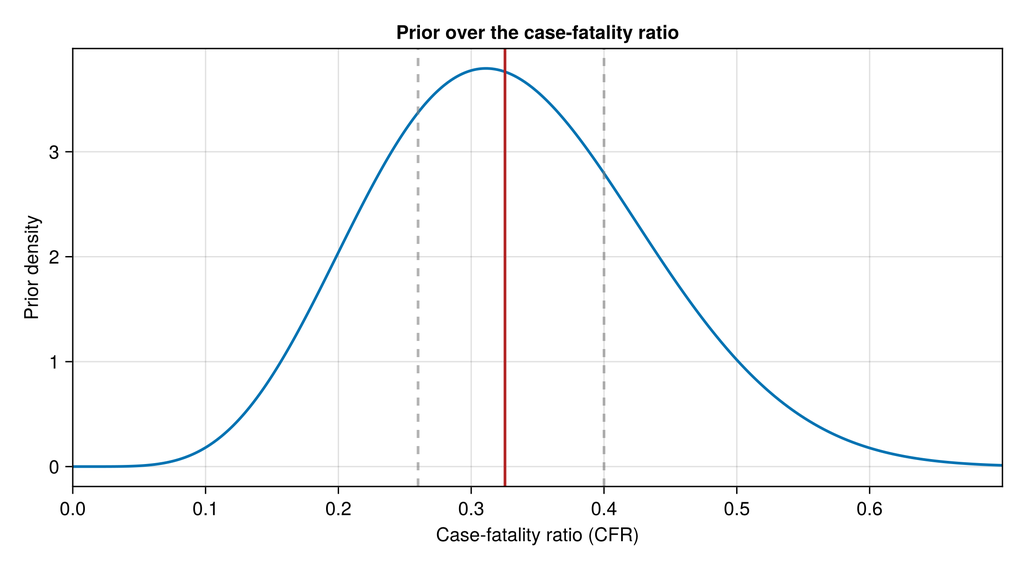

##### Detection window

is the mean time during which a case is still infectious and detectable abroad, the incubation plus onset-to-detection time. This rectangular window is the McCabe et al. mechanism, kept for the Imperial comparison; the default export model instead uses the onset-to-detection delay convolution described next. The prior is based on the detection windows McCabe et al. sweep in their Method 1 scenarios of 10, 15 and 20 days. It is centred on their central 15-day value with an SD wide enough to cover the 10–20 day range.

**Submodel: detection_window_model**

julia

```julia
@model function detection_window_model(;
        window_prior = truncated(Normal(15.0, 5.0); lower = 0))
    w ~ window_prior
    return (; w)
end
```

##### Infection→detection delay

The default export model replaces McCabe's fixed detection window with an explicit infection→detection delay convolution. Exports are travel-gated, so the at-risk clock starts at infection. A person travels during incubation, before symptoms, and is detected abroad only after the full infection→detection delay has elapsed. The at-risk prevalence is the difference between cumulative infections and the infections that have already completed infection→detection, and integrating this prevalence over the per-day per-capita travel rate gives the expected detected exports. The window form is recovered exactly as the infection→detection delay collapses to a point mass, so this generalises the McCabe assumption. The infection→detection delay is the incubation period convolved with the DRC onset-to-report delay , moment-matched to a single Gamma. Entering surveillance as a suspected case is taken to be the same process abroad as in the DRC, and the export count is a single datum that cannot identify its own delay, so the incubation and reported-cases streams pin it. Because the incubation period sits inside this delay, the export likelihoods carry no separate incubation rescale, and the survival is 1 at infection, unlike a flat onset rescale. Its mean is the incubation mean ( days) plus the onset-to-report mean ( days), days. The moment-match is an approximation: the sum of two Gammas is not Gamma, but matching the first two moments is accurate for the convex survival integrals here. The Imperial reproduction keeps the rectangular detection window for comparison.

##### Daily traveller volume

The number of people crossing from the source area to Uganda each day sets the travel rate in the exports likelihood. We treat it as an estimated quantity rather than a fixed input. McCabe et al. Table 3 records mean weekly passenger counts across seven points of entry; the Ituri-side daily total of is a sample mean across roughly - point-of-entry-weeks. We use a Normal prior centred on with SD , CV, truncated at zero, covering point-of-entry variation and the sitrep sampling uncertainty. The source population is kept fixed at the census value.

**Submodel: traveller volume**

julia

```julia
@model function traveller_volume_model(;
        mean::Real = ITURI_DAILY_TRAVEL,
        sd::Real = ITURI_DAILY_TRAVEL_SD)
    daily_travellers ~ truncated(Normal(mean, sd); lower = 0)
    return (; daily_travellers)
end
```

##### Surveillance dispersion

We assume the surveillance counts are reported with negative binomial observation error around their expected value, with a single shared dispersion for the suspected-death, reported-case and confirmed-case streams. Under the mean- / dispersion- parameterisation a count has

The dispersion captures passive-surveillance noise, namely under-reporting that varies by district, weekend reporting effects, and batched updates, not transmission heterogeneity. We judge this noise to be substantial, so a priori we expect meaningful overdispersion rather than near-Poisson counts. Following the Stan prior-choice recommendations (Stan Development Team, 2024), the dispersion is sampled on the scale, which behaves like a standard deviation, with a weakly-informative prior centred on that expected overdispersion,

giving a prior median near with a 90% range of about -. Because the prior allows near-Poisson counts, itself ranges over many orders of magnitude, so the pair plots and summary table show dispersion on both the sampled scale, which is easier to read, and the more familiar scale. This extends the McCabe et al. report, which uses a Poisson likelihood for the Method 2 deaths and does not model the reported case counts at all. The negative binomial adds overdispersion to absorb passive-surveillance noise.

**Submodel: surveillance_dispersion_model**

julia

```julia
@model function surveillance_dispersion_model(;
        inv_sqrt_k_prior = truncated(Normal(0.6, 0.2); lower = 0))
    inv_sqrt_k ~ inv_sqrt_k_prior
    k := 1.0 / (inv_sqrt_k^2 + eps(typeof(inv_sqrt_k)))
    return (; k, inv_sqrt_k)
end
```

##### Ascertainment — partial pooling between DRC and Uganda

Two surveillance systems detect cases: DRC passive surveillance (the reported suspected-case count) and Uganda's point-of-entry / hospital surveillance (the exported-case count). Each captures only a fraction of the true cases passing through it, and each fraction is informed by essentially a single aggregate data point, the one reported-case total and the one export count, so neither is well identified on its own. We therefore centre the prior on an assumed reporting fraction of 75% — most cases reach the suspected-case count under the active case finding in the response — and partially pool the two fractions so they share strength. Treating them as identical would conflate two different systems, while treating them as independent would leave the Uganda fraction almost wholly prior-driven.

Both ascertainment fractions and share a logit-scale hyperprior with mean and SD :

with . Here is the pooling strength: small pulls the two fractions together towards the shared-fraction limit, large lets them move independently towards the separate-fraction limit. The cases likelihood uses ; the two Uganda-side likelihoods use .

We sample this prior in its non-centred form: draw offsets and set . This is the same prior but avoids the funnel geometry of the centred form, which gave hundreds of divergent transitions.

**Submodel: pooled_ascertainment_model**

julia

```julia
@model function pooled_ascertainment_model(;
        mu_prior = Normal(logit(0.75), 1.0),
        tau_prior = truncated(Normal(0, 0.5); lower = 1e-4))
    μ_logit ~ mu_prior
    τ_logit ~ tau_prior
    z_drc ~ Normal(0, 1)
    z_uganda ~ Normal(0, 1)
    logit_p_drc = μ_logit + τ_logit * z_drc
    logit_p_uganda = μ_logit + τ_logit * z_uganda
    p_drc := logistic(logit_p_drc)
    p_uganda := logistic(logit_p_uganda)
    return (; μ_logit, τ_logit, p_drc, p_uganda)
end
```

We model both the deaths and the reported cases with a negative binomial, so we define one small constructor for it and share it. It is parameterised by mean and dispersion , so the variance is given by equation (8), with NaN / Inf-safe clamping on the success probability so extreme NUTS proposals during warmup do not trip the distribution domain check. It is used by the deaths and cases observation submodels below.

**Function: safe_nbinomial**

julia

```julia
function safe_nbinomial(k, μ)
    p_raw = k / (k + max(μ, eps(typeof(μ))))
    p = isfinite(p_raw) ?
        clamp(p_raw, eps(typeof(k)), one(k) - eps(typeof(k))) :
        eps(typeof(k))
    return NegativeBinomial(k, p)
end
```

#### Observation submodels

Each observation submodel takes the growth state as input, introduces the forward integral it needs, and ties one data stream to the latent . The forward integrals are solved numerically: the at-risk person-time integral for exports, the gamma convolution for deaths, and the deaths-among-exports convolution. Each submodel refers back to the parameters defined in equations (1)-(11).

##### Exports — Method 1 (geographic spread)

Each case in the source population travels to Uganda on any given day with probability , treating cases as exchangeable with the general population. A case is *detection-eligible* for days from infection (equation (7)). For a case infected at outbreak age , the accumulated probability of being detected in Uganda by is

Splitting at (full window elapsed before , partial window after) and summing across incidence gives the full export integral

which integration by parts collapses to the at-risk person-time form using the cumulative-incidence trajectory of equation (1):

For exponential growth this evaluates to . We evaluate equation (14) numerically so the same form works for any growth parameterisation, scale by the Uganda ascertainment fraction (equation (11)), and apply a Poisson likelihood:

Comparison with McCabe et al. / Imai 2020

McCabe et al. (and (Imai *et al.*, Jan 2020) before them) use the small- simplification , the limit of equation (14) as . For BVD's prior range the simplification under-estimates by roughly -. We use a Poisson likelihood for the detected exports; at the small detection probability here () it is indistinguishable from a binomial detection model.

**Submodel: exports_model**

julia

```julia
@model function exports_model(
        exported_cases::Union{Missing, Integer},
        growth_state, p_uganda::Real;
        source_population::Real = ITURI_POPULATION,
        window = detection_window_model(),
        traveller = traveller_volume_model(),
        onset_fraction::Real = 1.0)
    cumulative = growth_state.cumulative
    T = growth_state.T

    window_state ~ to_submodel(window, false)
    w = window_state.w

    travel_state ~ to_submodel(traveller, false)
    daily_travellers = travel_state.daily_travellers

    q = daily_travellers / source_population
    ## `onset_fraction` defaults to 1.0 so the McCabe-style window path is
    ## unchanged; pass the incubation mgf to onset-rescale the at-risk
    ## person-time if the window is interpreted as onset→detection.
    expected_exports_T := onset_fraction *
                          expected_exports(cumulative, p_uganda, q, T, w;
        r = growth_state.r)

    exported_cases ~ Poisson(expected_exports_T)

    return (; w, daily_travellers, p_uganda,
        expected_exports = expected_exports_T)
end
```

**Submodel: exports_delay_model (default)**

julia

```julia
@model function exports_delay_model(
        exported_cases::Union{Missing, Integer},
        growth_state, p_uganda::Real, f_det;
        source_population::Real = ITURI_POPULATION,
        traveller = traveller_volume_model(),
        last_offset::Real = 0)
    r = growth_state.r
    T = growth_state.T

    travel_state ~ to_submodel(traveller, false)
    daily_travellers = travel_state.daily_travellers

    q = daily_travellers / source_population
    ## The exports stopped accruing `last_offset` days before the cut-off
    ## (the last import), so the at-risk export integral runs only to
    ## `t_last = T - last_offset`. The latent size `growth_state.C_T` is
    ## still reported at the cut-off `T` by the caller.
    t_last = T - last_offset
    expected_exports_T := expected_exports_delay(r, p_uganda, q, t_last,
        f_det)

    exported_cases ~ Poisson(expected_exports_T)

    return (; f_det, daily_travellers, p_uganda,
        expected_exports = expected_exports_T)
end
```

##### Deaths — Method 2 (back-calculation from deaths)

Expected cumulative deaths by from a single seeding case is the CFR-weighted convolution of the cumulative-incidence trajectory (equation (1)) with the onset-to-death density (equation (4)):

For a gamma delay this integral has an exact closed form carrying a factor from the finite upper limit. McCabe et al. use the large- simplification , valid for , which drops that factor. We evaluate equation (16) numerically instead. Its Gamma CDF is differentiated under reverse-mode AD by a hand-written rule, with the shape-parameter derivative of the regularized incomplete gamma function from a Kummer series following the Stan Math Library (Carpenter *et al.*, 2015). The observed deaths follow the NegBinomial likelihood of equation (8) with the dispersion of equation (9), shared with the cases likelihood:

The DRC death count is *suspected* deaths, so it may include both missed BVD deaths under-reported and non-BVD deaths over-reported under the suspected case definition. A multiplicative drift factor absorbs that drift, with a tight prior centred at unity:

We do not see a single death total but a run of INSP sitreps, each reporting the deaths recorded since the last. Mapping each sitrep date to elapsed time , the new deaths in sitrep have mean

one term per sitrep sharing , with the first running from so a single death total recovers equation (17). The suspected-case and confirmed streams below are modelled the same way.

**Submodel: deaths_model**

julia

```julia
@model function deaths_model(
        total_deaths::AbstractVector,
        growth_state, k::Real, t_edges::AbstractVector;
        delay = delay_model(),
        cfr = cfr_model(),
        p_deaths::Real = 1.0,
        λ_bg_death::Real = 0.0,
        onset_fraction::Real = 1.0)
    r = growth_state.r

    delay_state ~ to_submodel(delay, false)
    cfr_state ~ to_submodel(cfr, false)
    f_death = delay_state.dist
    CFR = cfr_state.CFR

    n = length(t_edges)
    length(total_deaths) == n ||
        error("total_deaths length must match t_edges (got " *
              "$(length(total_deaths)) vs $n)")

    ## CFR-weighted cumulative expected BVD deaths at each bin edge. The
    ## latent trajectory is cumulative *infections*, so `onset_fraction`
    ## (the incubation mgf) maps it onto onsets before the onset-to-death
    ## convolution; the drift factor `p_deaths` scales the whole
    ## trajectory.
    μ_BVD_at_edges = [s <= zero(s) ? zero(s) :
                      p_deaths * onset_fraction *
                      delay_convolution(CFR, r, s, f_death)
                      for s in t_edges]

    ## Constant-rate non-BVD background, the death analogue of the case
    ## `λ_bg`: cumulative μ_bg_death(s) = λ_bg_death·s, so the suspect-death
    ## cumulative is the BVD trajectory plus this linear background. The
    ## per-bin NegBinomial mean is the between-edge increment of the total
    ## (with a NaN / Inf-safe positive clamp via `daily_increment_kernel`).
    Tt = typeof(μ_BVD_at_edges[1] * float(λ_bg_death))
    Λ_at_edges = Vector{Tt}(undef, n)
    for i in 1:n
        s_k = t_edges[i]
        μ_bg_k = max(convert(Tt, λ_bg_death) * s_k, zero(Tt))
        Λ_at_edges[i] = convert(Tt, μ_BVD_at_edges[i]) + μ_bg_k
    end
    bin_means = daily_increment_kernel(Λ_at_edges)

    for i in 1:n
        total_deaths[i] ~ safe_nbinomial(k, bin_means[i])
    end

    expected_deaths_T := Λ_at_edges[end]

    return (; CFR, p_deaths, λ_bg_death, delay_dist = f_death,
        expected_deaths_T, Λ_at_edges, μ_BVD_at_edges)
end
```

##### Reported cases

is the latent cumulative *infection* count (equation (1)), not a count of reported, tested or confirmed cases. The BVD-driven suspected term acts on the *onset* trajectory, infections mapped through the incubation period, written as below in the same shorthand as the deaths convolution (equation (16)). Suspected reports also include test-negative referrals such as malaria or other febrile illness, whose rate we assume is set by background prevalence and surveillance intensity, not by BVD growth. We therefore model the suspected stream as the sum of a BVD-driven component and a non-BVD background that accrues with elapsed surveillance time:

is the expected non-BVD suspected reports per day. The implied per-suspected positivity at the cut-off is , distinct from the per-test positivity used by the lab pipeline below. Half-Normal prior:

The prior is informative because is degenerate with outbreak size: the per-bin reported mean is , so a diffuse prior lets the background absorb arbitrarily many suspected cases and resolve at the high end where the deaths and exports streams pin . The background must not explain more suspected cases than were ever reported, so the SD of is chosen from the observed suspected total at the May cut-off over the elapsed window days. It puts the median background at per day, cases or of observed, and the prior bound at per day, cases or of observed. A wider SD () leaves a second posterior mode in which runs to per day and the background explains the majority of suspected cases; SD keeps the fit in the regime where the BVD trajectory drives the suspected total. is identified from the suspected/confirmed contrast and from the samples-received series, which conditions on the combined BVD and background backlog. The dispersion (equation (9)) is shared with the deaths and confirmed likelihoods.

assumes the non-BVD background rate is constant in time and independent of the outbreak. With a single cumulative suspected count we can only identify a cumulative rate, so we keep the constant-rate parameterisation.

As for the deaths, we model each sitrep's new suspected cases rather than only the latest cumulative total. The DRC ascertainment fraction (equation (11)) is applied to every sitrep's increment. Writing the unit-ascertainment BVD-suspected cumulative as , the new suspected cases in sitrep have mean

##### Per-sitrep conditional predictive

The per-sitrep increment likelihoods (equations (17b) and (20)) give a matching per-sitrep diagnostic. Let a stream have observed cumulative counts at the sitrep edges. The conditional one-step-ahead predictive of the cumulative at sitrep conditions on the *observed* previous cumulative and predicts only the new increment,

where is the posterior-predictive between-vintage increment for bin , a draw from , the same increment the model samples in predictive mode. This is the "filtered" one-step-ahead predictive. It differs from reconstructing the cumulative as the running sum of the modelled increments , whose errors compound across sitreps because every step builds on earlier modelled increments rather than on what was observed. Conditioning each step on the observed previous cumulative isolates the model's one-step increment prediction, so a mismatch at one sitrep is attributed to that sitrep alone and does not propagate down the series.

**Submodel: test_positivity_model**

julia

```julia
@model function test_positivity_model(;
        lambda_prior = truncated(Normal(0.0, 1.0); lower = 0),
        fraction_forwarded_prior = Beta(5.0, 2.0),
        sample_forward::Bool = true)
    λ_bg ~ lambda_prior
    if sample_forward
        τ_forward ~ fraction_forwarded_prior
    else
        ## Queue path: forwarding is governed by `1 − e` from the
        ## exclusion submodel, so `τ_forward` is a fixed constant and is
        ## not sampled (avoids a dead posterior dimension).
        τ_forward = one(λ_bg)
    end
    return (; λ_bg, τ_forward)
end
```

**Submodel: reported_cases_model**

julia

```julia
@model function reported_cases_model(
        reported_cases::AbstractVector,
        growth_state, k::Real,
        p_drc_per_bin::AbstractVector, t_edges::AbstractVector;
        report_delay = report_delay_model(),
        test_positivity = test_positivity_model(),
        report_onset_offset::Union{Nothing, Real} = nothing,
        onset_fraction::Real = 1.0)
    report_state ~ to_submodel(report_delay, false)
    test_positivity_state ~ to_submodel(test_positivity, false)
    λ_bg = test_positivity_state.λ_bg
    τ_forward = test_positivity_state.τ_forward
    f_rep = report_state.dist
    r = growth_state.r

    n = length(t_edges)
    n == length(p_drc_per_bin) ||
        error("p_drc_per_bin length must match t_edges (got " *
              "$(length(p_drc_per_bin)) vs $n)")
    n == length(reported_cases) ||
        error("reported_cases length must match t_edges (got " *
              "$(length(reported_cases)) vs $n)")

    ## Unit-ascertainment BVD cumulative onsets at each bin edge (Gamma
    ## closed form), the infection trajectory mapped onto onsets by
    ## `onset_fraction` (the incubation mgf). Per-bin ascertainment is
    ## applied below on the between-edge increment so each bin's mean
    ## tracks its own random-effect draw.
    μ_BVD0_at_edges = [s <= zero(s) ? zero(s) :
                       onset_fraction *
                       delay_convolution(one(eltype(p_drc_per_bin)),
                           r, s, f_rep) for s in t_edges]
    ΔμBVD0 = daily_increment_kernel(μ_BVD0_at_edges)

    Tt = eltype(ΔμBVD0)
    Λ_at_edges = Vector{Tt}(undef, n)
    bin_means = Vector{Tt}(undef, n)
    Λ_prev = zero(Tt)
    μ_bg_prev = zero(Tt)
    for i in 1:n
        s_k = t_edges[i]
        ## Constant-rate non-BVD background: cumulative μ_bg(s_k) = λ_bg·s_k,
        ## so the between-edge increment is λ_bg·(s_k − s_{k−1}).
        μ_bg_k = max(λ_bg * s_k, zero(Tt))
        Δμ_bg = max(μ_bg_k - μ_bg_prev, zero(Tt))
        μ_bg_prev = μ_bg_k
        raw = p_drc_per_bin[i] * ΔμBVD0[i] + Δμ_bg
        μ_i = isfinite(raw) ? max(raw, eps(typeof(raw))) :
              eps(typeof(raw))
        bin_means[i] = μ_i
        Λ_prev += μ_i
        Λ_at_edges[i] = Λ_prev
    end

    for i in 1:n
        reported_cases[i] ~ safe_nbinomial(k, bin_means[i])
    end

    ## Implied per-suspected positivity at the cut-off (BVD share of the
    ## expected suspected total). Exposed for comparison with the sitrep.
    μ_BVD_cum = sum(p_drc_per_bin[i] * ΔμBVD0[i] for i in 1:n)
    positivity := μ_BVD_cum / Λ_at_edges[end]

    expected_reports_total := Λ_at_edges[end]

    return (; p_drc_per_bin, λ_bg, τ_forward,
        expected_reports_total, positivity,
        report_delay_dist = f_rep,
        μ_BVD0_at_edges, Λ_at_edges)
end
```

##### Confirmed cases and samples received

The laboratory pipeline observes three per-vintage series: the samples received from the suspected pool, the samples analysed, and the confirmed (PCR-positive) cases. We model it as a throughput queue. The suspected backlog reaches the lab after a transport delay, the lab analyses a capacity-limited slice of the received backlog each window, and the confirmed count is the positivity-thinned analysed slice. Some vintages carry a published analysed denominator (23-28 May); the early 18-22 May and late 29 May-3 June windows are dark (no national analysed total), and the queue owns them.

The cumulative suspect backlog at each vintage is the BVD-suspected term of equation (18) plus the non-BVD background, . Specimens reach the lab after a receipt delay , so the received backlog is convolved with that delay, and the per-window received increment is observed through a NegBinomial,

The lab drains the received backlog at a capacity-limited rate: with daily capacity over window length and standing backlog , the analysed mean is — the whole backlog when capacity is ample, capacity-limited when it is not. On windows with a published analysed count the denominator is conditioned and the confirmed count is a Binomial thinning of it; on dark windows the denominator is integrated out via the exact Poisson-thinned marginal,

Per-test positivity mixes true and false positives. With PCR sensitivity , specificity and the BVD share of the analysed batch at vintage ,

The tested BVD share follows the composition link. The lab triages the severest, most-likely-BVD cases first, so it over-tests BVD early; the enrichment then relaxes to the suspect-pool composition as testing widens. The enrichment decays on the analysed-VOLUME clock , so a lab stall pauses the relaxation,

Tying to makes the confirmed/positivity data identify the non-BVD background rather than a free curve. A per-vintage partially-pooled logit-scale offset lets each window's positivity fit the non-monotone wobble while stays fixed.

The priors are a Beta on the PCR sensitivity, a high Beta on the specificity, and a moderate half-normal on the severity enrichment with a half-normal decay timescale:

Confirmation runs on the altona RealStar Filovirus Screen RT-PCR at INRB. The rapid Cepheid GeneXpert Ebola assay is Zaire-ebolavirus-specific and does not reliably detect Bundibugyo virus (Cepheid, 2020). The RealStar kit detects Bundibugyo virus at - RNA copies per reaction in laboratory and field evaluation (Rieger *et al.*, 2016) but has no published field sensitivity for this variant, and early low-viral-load specimens and field handling lower real-world detection. The prior, mean and interval -, keeps good analytical sensitivity plausible while carrying substantial downside mass for those field losses. The specificity prior is tight and high, mean , reflecting the assay's strong analytical specificity and keeping the false-positive term from absorbing the positivity signal.

The severity enrichment is moderate and bounded below at zero: for a pool composition the early tested share is , not near-pure BVD, since other severe febrile illness is also triaged. The decay prior has median volume units, spanning the lab window. Outbreak size stays pinned by the deaths and exports streams and the received counts, with carrying the positivity.

**Submodel: test_sensitivity_model**

julia

```julia
@model function test_sensitivity_model(;
        sensitivity_prior = Beta(6.0, 2.0))
    s_test ~ sensitivity_prior
    return (; s_test)
end
```

**Submodel: confirmed_cases_model**

julia

```julia
@model function confirmed_cases_model(
        confirmed_cases::AbstractVector,
        samples_analysed::AbstractVector,
        samples_received::AbstractVector,
        tests_analysed::Union{Missing, Integer},
        growth_state, k::Real,
        p_drc_per_bin::AbstractVector, λ_bg::Real, τ_forward::Real, f_rep,
        t_edges::AbstractVector, tests_edge::Real;
        test_sensitivity = test_sensitivity_model(),
        test_specificity = test_specificity_model(),
        severity_enrichment = severity_enrichment_model(),
        receipt_delay = lab_receipt_delay_model(),
        capacity_model = lab_capacity_model,
        capacity_centre::Real = 150.0,
        report_onset_offset::Union{Nothing, Real} = nothing,
        q_random_effect = confirmed_q_re_model,
        epi_exclusion = nothing,
        volume_scale::Real = 200.0,
        onset_fraction::Real = 1.0)
    sensitivity_state ~ to_submodel(test_sensitivity, false)
    specificity_state ~ to_submodel(test_specificity, false)
    ## Composition-linked positivity. The tested BVD share is tied to the
    ## suspect-pool composition `φ = μ_BVD/(μ_BVD+μ_bg)` upsampled by a
    ## decaying severity enrichment `δ0` (see [`severity_enrichment_model`]
    ## (@ref)), so the positivity data identify the background `λ_bg` rather
    ## than a free curve.
    enrich_state ~ to_submodel(severity_enrichment, false)
    δ0 = enrich_state.δ0
    decay_scale = enrich_state.decay_scale
    receipt_state ~ to_submodel(receipt_delay, false)
    ## Epi-exclusion fraction `e` for the throughput queue: the share of
    ## suspects ruled out by epi follow-up and never sampled, so the
    ## received backlog asymptotes to `(1 − e)·N_susp`. Default OFF (e = 0,
    ## forward = 1) for the headline fit; the opt-in Beta(2, 12) prior is a
    ## sensitivity arm.
    if epi_exclusion !== nothing
        epi_state ~ to_submodel(epi_exclusion, false)
        forward_frac = epi_state.forward
    else
        forward_frac = nothing
    end
    n_edges_re = length(t_edges)
    if q_random_effect !== nothing
        q_re_state ~ to_submodel(q_random_effect(n_edges_re), false)
        σ_q = q_re_state.σ_q
        z_q = q_re_state.z_q
    else
        σ_q = nothing
        z_q = nothing
    end
    n_edges = length(t_edges)
    capacity_state ~ to_submodel(
        capacity_model(n_edges; capacity_centre = capacity_centre), false)
    s_test = sensitivity_state.s_test
    spec_test = specificity_state.spec_test
    ## `δ0`, `decay_scale` are set above by the severity-enrichment submodel.
    f_receipt = receipt_state.dist
    κ = capacity_state.capacity
    r = growth_state.r
    T = growth_state.T

    n = length(t_edges)
    n == length(p_drc_per_bin) ||
        error("p_drc_per_bin length must match t_edges (got " *
              "$(length(p_drc_per_bin)) vs $n)")
    n == length(confirmed_cases) ||
        error("confirmed_cases length must match t_edges (got " *
              "$(length(confirmed_cases)) vs $n)")
    n == length(samples_analysed) ||
        error("samples_analysed length must match t_edges (got " *
              "$(length(samples_analysed)) vs $n)")
    n == length(samples_received) ||
        error("samples_received length must match t_edges (got " *
              "$(length(samples_received)) vs $n)")

    ## Cumulative suspect backlog at each edge, split BVD / background. The
    ## BVD-suspected cumulative is `μ_BVD(s) = p_DRC · onset_fraction ·
    ## ∫₀^s e^{r u} f_rep(s−u) du` (the onset→report Gamma closed form, the
    ## same quantity the reported stream produces); the non-BVD background
    ## cumulative is `μ_bg(s) = λ_bg · s` (constant-rate). Their sum
    ## `N_susp,v` is the backlog the received-count likelihood conditions on
    ## (below). Their ratio `μ_BVD / N_susp` is the count-implied BVD
    ## composition `φ`, the plateau the composition link relaxes to.
    t_report = report_onset_offset === nothing ? zero(T) :
               max(T - report_onset_offset, zero(T))

    Tt = typeof(float(r) * float(λ_bg) * onset_fraction *
                float(δ0) * float(decay_scale))
    ## Per-edge analysed denominator: the observed analysed increment where
    ## present, else zero (dark windows are owned by the Poisson-thinned
    ## marginal below). Both the volume clock and the confirmed Binomial use
    ## this.
    A_imp = Vector{Tt}(undef, n)
    for i in 1:n
        A_imp[i] = samples_analysed[i] === missing ? zero(Tt) :
                   convert(Tt, samples_analysed[i])
    end
    p_pos = Vector{Tt}(undef, n)
    q_at = Vector{Tt}(undef, n)
    qinf_count_at = Vector{Tt}(undef, n)
    Nsusp_at = Vector{Tt}(undef, n)
    Λ_at_edges = Vector{Tt}(undef, n)
    ## Composition-linked positivity with modelled specificity. The tested
    ## BVD share is the suspect-pool composition `φ = μ_BVD/(μ_BVD+μ_bg)`
    ## upsampled by a severity log-odds enrichment `δ0·exp(−c/decay)` that
    ## decays as testing widens, so `q → φ` at the plateau. The per-test
    ## positivity combines true and false positives,
    ##   p_pos = s·q + (1 − spec)·(1 − q),
    ## with `1 − spec` the false-positive rate. The binomial conditions on
    ## the observed analysed denominator.
    ## Cumulative analysed volume at each edge, for the volume-indexed
    ## clock. The severe-first share then relaxes with how many samples have
    ## been processed rather than calendar time, so a lab stall (no new
    ## analysed) does not advance the curve.
    analysed_cum_at = Vector{Tt}(undef, n)
    acc_a = zero(Tt)
    for i in 1:n
        acc_a += A_imp[i]
        analysed_cum_at[i] = acc_a
    end
    for i in 1:n
        s_i = oftype(T, t_edges[i])
        μ_bvd = s_i <= zero(s_i) ? zero(Tt) :
                convert(Tt, p_drc_per_bin[i]) * onset_fraction *
                delay_convolution(one(r), r, s_i, f_rep)
        μ_bg = max(convert(Tt, λ_bg) * s_i, zero(Tt))
        denom = μ_bvd + μ_bg
        Nsusp_at[i] = denom
        qinf_count_at[i] = denom > zero(Tt) ?
                           clamp(μ_bvd / denom, zero(Tt), one(Tt)) :
                           zero(Tt)
        ## Volume clock for the severity enrichment: cumulative analysed
        ## volume in units of `volume_scale` samples, so a lab stall (no new
        ## analysed) pauses the relaxation.
        c_i = analysed_cum_at[i] / convert(Tt, volume_scale)
        ## Composition link: the suspect-pool composition
        ## φ = μ_BVD/(μ_BVD+μ_bg) upsampled by a decaying severity log-odds
        ## enrichment δ0·exp(−c/decay), so the lab over-tests BVD early and
        ## relaxes to the pool composition as testing widens, tying
        ## positivity to the background μ_bg.
        φ = clamp(qinf_count_at[i], eps(Tt), one(Tt) - eps(Tt))
        δ_i = convert(Tt, δ0) * exp(-c_i / convert(Tt, decay_scale))
        q_base = logistic(logit(φ) + δ_i)
        ## Optional partially-pooled per-window offset on the tested BVD
        ## share, logit-scale, so each vintage's positivity can fit the
        ## non-monotone wobble while `s` stays fixed. `σ_q → 0` recovers the
        ## smooth baseline curve.
        if z_q === nothing
            q = q_base
        else
            qb = clamp(q_base, eps(Tt), one(Tt) - eps(Tt))
            q = clamp(
                logistic(logit(qb) + convert(Tt, σ_q) * convert(Tt, z_q[i])),
                zero(Tt), one(Tt))
        end
        q_at[i] = q
        p_raw = s_test * q + (one(Tt) - spec_test) * (one(Tt) - q)
        p_pos[i] = isfinite(p_raw) ?
                   clamp(p_raw, eps(Tt), one(Tt) - eps(Tt)) : eps(Tt)
        ## Expected confirmed increment: newly-analysed slice ΔA_v times its
        ## positivity (a diagnostic). Uses the imputed denominator where the
        ## analysed count is missing.
        Λ_at_edges[i] = p_pos[i] * A_imp[i]
    end
```

```julia
    ## Received queue: the suspect backlog reaches the lab after a transport
    ## delay, so the cumulative received is the suspect backlog convolved with
    ## the receipt-delay kernel f_receipt. Confirmed uses a pooled (constant)
    ## p_drc, so a single representative value drives the continuous backlog.
    ## Built before the confirmed likelihood because the queue path's
    ## per-window analysed mean μ_A depends on this received backlog.
    p_drc_c = convert(Tt, p_drc_per_bin[1])
    N_susp_fn = let r = r, f_rep = f_rep, p_drc_c = p_drc_c,
        onset_fraction = onset_fraction, λ_bg = λ_bg

        u -> u <= zero(u) ? zero(Tt) :
             p_drc_c * onset_fraction *
             delay_convolution(one(r), r, u, f_rep) +
             max(convert(Tt, λ_bg) * u, zero(Tt))
    end
    N_recv_at = Vector{Tt}(undef, n)
    for i in 1:n
        s_i = oftype(T, t_edges[i])
        raw = s_i <= zero(s_i) ? zero(Tt) :
              convert(Tt, delay_convolution(N_susp_fn, s_i, f_receipt))
        N_recv_at[i] = max(raw, zero(Tt))
    end

    ## Forwarded fraction of the received backlog `(1 − e)` from the
    ## epi-exclusion submodel (default `e = 0`, forward = 1).
    fwd = forward_frac === nothing ? one(Tt) : convert(Tt, forward_frac)

    ## Per-window predicted analysed mean μ_A from the capacity-limited drain
    ## of the received backlog. Computed for ALL windows (the queue path needs
    ## μ_A for the dark windows that lack an observed denominator). Window 1's
    ## cumulative analysed (observed or predicted) is the initial condition.
    μ_A_at = Vector{Tt}(undef, n)
    let analysed_cum = zero(Tt)
        for i in 1:n
            ## Window 1 has no preceding edge. Use the spacing to the next
            ## vintage as the representative window length, NOT the full
            ## seeding-to-edge-1 elapsed time: the latter (≈ t_edges[1],
            ## ~120 days) makes cap ≫ backlog and drains the entire
            ## pre-window received backlog in one step, blowing up the
            ## first dark window's μ_A. A single-vintage fit falls back to
            ## the cumulative.
            Δt = if i == 1
                n >= 2 ?
                max(oftype(T, t_edges[2]) - oftype(T, t_edges[1]),
                    zero(T)) :
                max(oftype(T, t_edges[1]), zero(T))
            else
                max(oftype(T, t_edges[i]) - oftype(T, t_edges[i - 1]),
                    zero(T))
            end
            recv_cum = fwd * N_recv_at[i]
            backlog = max(recv_cum - analysed_cum, eps(Tt))
            cap = max(convert(Tt, κ[i]) * Δt, zero(Tt))
            μ_A_raw = backlog * (one(Tt) - exp(-cap / backlog))
            μ_A_at[i] = isfinite(μ_A_raw) ? max(μ_A_raw, eps(Tt)) : eps(Tt)
            ## Advance the analysed cumulative by the observed increment where
            ## present, else the predicted mean (carries the queue through the
            ## dark windows).
            analysed_cum += samples_analysed[i] === missing ? μ_A_at[i] :
                            convert(Tt, samples_analysed[i])
        end
    end

    ## Coherent lab-throughput queue with a Poisson-thinned denominator.
    ## OBSERVED-denominator windows condition on the real analysed
    ## increment: confirmed_v ~ Binomial(ΔA_obs, p_pos) AND
    ## ΔA_obs ~ Poisson(μ_A) (pins positivity and capacity). DARK windows
    ## (no published analysed) use the exact marginal of
    ## Binomial(Poisson(μ_A), p_pos), namely
    ## confirmed_v ~ Poisson(μ_A · p_pos): the denominator is integrated
    ## out, NOT a free latent, so there is no per-vintage funnel.
    for i in 1:n
        if samples_analysed[i] === missing
            μ_c = isfinite(μ_A_at[i] * p_pos[i]) ?
                  max(μ_A_at[i] * p_pos[i], eps(Tt)) : eps(Tt)
            confirmed_cases[i] ~ Poisson(μ_c)
        else
            samples_analysed[i] ~ Poisson(μ_A_at[i])
            A_i = Int(samples_analysed[i])
            confirmed_cases[i] ~ Binomial(A_i, p_pos[i])
        end
    end

    ## Received increments observed where present, mean (1 − e)·ΔN_recv.
    ΔN_recv = daily_increment_kernel(N_recv_at)
    recv_means = Vector{Tt}(undef, n)
    for i in 1:n
        raw = fwd * ΔN_recv[i]
        recv_means[i] = isfinite(raw) ? max(raw, eps(Tt)) : eps(Tt)
        samples_received[i] === missing && continue
        samples_received[i] ~ safe_nbinomial(k, recv_means[i])
    end

    ## Per-test positivity at the lab cut-off (last edge ≤ tests_edge):
    ## exposed for comparison with the sitrep `Taux de positivité`.
    te_idx = something(
        findlast(
            i -> t_edges[i] <= tests_edge + sqrt(eps(typeof(tests_edge))),
            1:n), n)
    p_positive := p_pos[te_idx]
    q_cutoff := q_at[te_idx]
    ## Plateau tested share: the severity enrichment relaxes to the pool
    ## composition, so the plateau is the count-implied composition itself.
    q_baseline := qinf_count_at[te_idx]
    q_baseline_count := qinf_count_at[te_idx]
    δ0_out := δ0
    τ_forward_out := τ_forward
    ## Daily analysis capacity at the cut-off vintage (samples/day).
    capacity_cutoff := κ[te_idx]

    ## Cumulative expected totals at the cut-off: sum the per-window
    ## increment means (confirmed positives, received samples).
    expected_confirmed_total := sum(Λ_at_edges)
    expected_received_total := sum(recv_means)

    ## Queue-path diagnostic: the predicted analysed denominator μ_A summed
    ## over the dark windows (those without a published analysed count). Lets
    ## the dark-window denominators be compared against the observed 23-28 May
    ## anchors.
    dark_analysed_total := sum(samples_analysed[i] === missing ? μ_A_at[i] :
                               zero(eltype(μ_A_at)) for i in 1:n)
    ## Per-window predicted analysed mean and received mean, exposed for the
    ## dark-window-versus-anchor comparison and the received posterior check.
    μ_A_pred := copy(μ_A_at)
    recv_pred := copy(recv_means)

    return (; p_positive, p_pos, q_at, qinf_count_at, Nsusp_at,
        N_recv_at, recv_means, μ_A_at, dark_analysed_total, capacity = κ,
        s_test, spec_test, δ0, decay_scale, τ_forward, p_drc_per_bin,
        expected_confirmed_total, expected_received_total, Λ_at_edges)
end
```

##### Deaths among exports

Uganda reports a single death among its detected exports. That count is informative. If the exports happened long ago, we would expect more deaths among them by now under the onset-to-death gamma, so the observed deaths-among-exports bound how recently the exports occurred and help constrain and . The expected count reuses the at-risk export integrand of equation (14) but weights each case by its probability of having died by , the onset-to-death CDF (equation (4)), then scales by the CFR, the travel rate and the Uganda ascertainment fraction :

Equation (19) is evaluated numerically, writing as the inner integral of the density so the whole expression differentiates through alone, since the reverse-mode AD backend does not support the gamma CDF shape-parameter derivative. The detection window and daily traveller volume are shared with the exports likelihood so the two Uganda-side observations use the same person-time.

Equation (19) is the McCabe-window form, kept for the comparison. In the default delay mechanism the top-hat window is replaced by the infection→detection survival , and the death CDF is the infection→death delay, incubation onset-to-death, so both clocks run from infection in step with . Detection and death share the same onset, so incubation enters both delays, a slight accepted double-count of the shared incubation period.

Uganda's export deaths are point-of-entry or hospital-detected, so their dates are recorded directly and carry information beyond the total count: a death seen early bounds how old the outbreak can be. We model the detected export deaths as an inhomogeneous Poisson process with cumulative intensity (equation (19), at any elapsed time ) and use its time-resolved likelihood. Split at the earliest dated death, offset before the cut-off at elapsed time . Before it no export death was seen, contributing one continuous survival term over . From that day to the cut-off each day carries a Poisson count of the export deaths that day, with bin mean ,

This is the same per-bin construction as the DRC streams, differencing the cumulative expected count between successive dates as in equation (20b), with one addition: the continuous survival weight over the long pre-death zero stretch before the first dated death. That term collapses the run of pre-death zeros into a single weight, so there is no per-day vector of zeros, while the recent window is resolved per day. It is used here because the exact export-death dates are known; the DRC streams have no such fixed zero stretch and are differenced only across the reported sitrep dates. The number of daily bins is fixed by the earliest death's date, so the likelihood is well defined even though is latent. With one death the series is a single count, and it takes more dated deaths as they are reported.

Selection-bias caveat

This assumes Uganda's surveillance retains detected exports through to any subsequent death. If the system instead loses cases that progress to death, the observed deaths-among-exports count is selection-biased downward and the constraint it places on is overstated.

**Submodel: exports_deaths_model**

julia

```julia
@model function exports_deaths_model(
        export_deaths_daily::AbstractVector,
        growth_state, CFR::Real, delay_dist, p_uganda::Real;
        pre_start_deaths::Union{Missing, Integer} = 0,
        window::Real,
        daily_travellers::Real,
        source_population::Real = ITURI_POPULATION,
        onset_fraction::Real = 1.0)
    cumulative = growth_state.cumulative
    T = growth_state.T
    q = daily_travellers / source_population
    n = length(export_deaths_daily)   # days from earliest death to cut-off

    ## Precompute the onset-to-death CDF once and reuse it across every
    ## bin edge below (`T - s ≤ window` over the domain; see
    ## `ExportDeathDelay`). The latent trajectory is cumulative
    ## *infections*, so `onset_fraction` (the incubation mgf) maps it onto
    ## onsets before the onset-to-death convolution.
    delay = ExportDeathDelay(delay_dist, window)
    Λ(t) = onset_fraction * expected_exports_deaths(
        cumulative, delay, CFR, p_uganda, q, t, window)

    ## Pre-death zero stretch as one Poisson observed at 0; `missing`
    ## generates it for predictive checks (see equation (20)).
    pre = T - n > zero(T) ? Λ(T - n) : zero(T)
    pre_start_deaths ~ Poisson(max(pre, zero(pre)))

    ## Per-day means via the shared between-edge differencing
    ## (`daily_increment_kernel`), the same construction as the DRC
    ## streams but starting from the pre-death survival weight `pre`
    ## rather than zero.
    Λ_at_edges = [Λ(T - n + i) for i in 1:n]
    μ_day = daily_increment_kernel(Λ_at_edges, pre)
    for i in 1:n
        export_deaths_daily[i] ~ Poisson(μ_day[i])
    end

    return (;)
end
```

**Submodel: exports_deaths_delay_model (default)**

julia

```julia
@model function exports_deaths_delay_model(
        export_deaths_daily::AbstractVector,
        growth_state, CFR::Real, delay_dist, p_uganda::Real;
        pre_start_deaths::Union{Missing, Integer} = 0,
        last_offset::Real = 0,
        f_det,
        daily_travellers::Real,
        source_population::Real = ITURI_POPULATION)
    r = growth_state.r
    T = growth_state.T
    q = daily_travellers / source_population
    n = length(export_deaths_daily)   # earliest death to last series day

    ## The series ends `last_offset` days before the cut-off (the date of
    ## the most recent reported import to Uganda). Like the export-case
    ## stream, this travel-gated death stream is only run up to that day:
    ## movement patterns likely shift and the days after the last import
    ## are right-truncated by reporting lag. The at-risk clock anchors on
    ## this date.
    t_last = T - last_offset

    ## One at-risk trajectory over [0, t_last] shared across every edge,
    ## the same engine as the export-case stream. The per-edge intensity
    ## is the infection-keyed delay-survival weight: the infection→death
    ## CDF weighted by the infection→detection survival (1 at age 0).
    traj = ExportRiskTrajectory(t_last, r)
    edges = [t_last - n + i for i in 0:n]
    Λ = (CFR * p_uganda * q) .*
        export_death_at_risk(traj, edges, f_det, delay_dist)

    ## Pre-death zero stretch as one Poisson observed at 0; `missing`
    ## generates it for predictive checks.
    pre = max(Λ[1], zero(eltype(Λ)))
    pre_start_deaths ~ Poisson(pre)

    ## Per-day means via the shared between-edge differencing, starting
    ## from the pre-death survival weight `pre`.
    μ_day = daily_increment_kernel(Λ[2:end], pre)
    for i in 1:n
        export_deaths_daily[i] ~ Poisson(μ_day[i])
    end

    return (;)
end
```

##### First export detection — timing survival term

The same logic applies to the *first detected export case* (Uganda's first hospital admission), using the at-risk export person-time intensity (equation (15)) in place of the export-death intensity. With the offset from the first admission date to the cut-off and ,

As with the export-death term, this is one-sided and only marginally constrains the posterior because the Uganda detections sit only days before the cut-off.

**Submodel: exports_detection_timing_model**

julia

```julia
@model function exports_detection_timing_model(
        growth_state, p_uganda::Real;
        delta::Union{Missing, Real},
        pre_detection_exports::Union{Missing, Integer} = 0,
        window::Real,
        daily_travellers::Real,
        source_population::Real = ITURI_POPULATION)
    if !ismissing(delta)
        cumulative = growth_state.cumulative
        T = growth_state.T
        t1 = T - delta
        q = daily_travellers / source_population
        survived_exports := t1 <= zero(T) ? zero(T) :
                            expected_exports(cumulative, p_uganda, q, t1,
            window; r = growth_state.r)
        ## No detection before t1 as a Poisson observed at 0; `missing`
        ## generates it for predictive checks (see equation (22)).
        pre_detection_exports ~ Poisson(max(survived_exports, zero(T)))
    end

    return (;)
end
```

**Submodel: exports_detection_timing_delay_model (default)**

julia

```julia
@model function exports_detection_timing_delay_model(
        growth_state, p_uganda::Real;
        delta::Union{Missing, Real},
        pre_detection_exports::Union{Missing, Integer} = 0,
        f_det,
        daily_travellers::Real,
        source_population::Real = ITURI_POPULATION)
    if !ismissing(delta)
        r = growth_state.r
        T = growth_state.T
        t1 = T - delta
        q = daily_travellers / source_population
        survived_exports := t1 <= zero(T) ? zero(T) :
                            expected_exports_delay(r, p_uganda, q, t1,
            f_det)
        ## No detection before t1 as a Poisson observed at 0; `missing`
        ## generates it for predictive checks.
        pre_detection_exports ~ Poisson(max(survived_exports, zero(T)))
    end

    return (;)
end
```

#### Composers

These composers combine the building blocks into the full model for each analysis. McCabe et al. invert a deterministic summary formula at fixed nuisance parameters; here we sample all of them — growth, delay, CFR, detection window, traveller volume, dispersion, ascertainment — and condition on the observed counts. Each composer includes only the likelihoods for the streams it carries, so a single-stream composer never instantiates the other observation submodels. Of the observation streams, the geographic-spread exports reproduce McCabe et al.'s Method 1 and the back-calculation from deaths their Method 2; the reported-cases ascertainment, the deaths-among-exports, the export-detection-timing, and the genetic seeding terms are extensions with no counterpart in McCabe et al.

The joint composer samples a single dispersion scale and passes it to both the deaths and cases likelihoods, so they share one passive- surveillance noise scale. It samples one pooled set of ascertainment fractions, threading to the cases likelihood and to the two Uganda-side likelihoods. The window and daily traveller volume sampled by the exports likelihood are reused by the deaths-among-exports likelihood so the two share person-time.

We write single-stream composers for the four count-based streams only. The export-detection-timing and genetic seeding terms constrain the outbreak start rather than the size directly and are weakly identified in isolation, so we do not fit them on their own. The joint composer still conditions on both.

##### Exports-only fit — Method 1 analogue

**Composer: exports-only fit**

julia

```julia
@model function exports_only_model(
        exported_cases::Union{Missing, Integer};
        growth = exponential_growth_model(),
        exports = exports_delay_model,
        report_delay = report_delay_model(),
        ascertainment = pooled_ascertainment_model(),
        incubation = incubation_model(),
        export_last_offset::Real = 0)
    growth_state ~ to_submodel(growth, false)
    asc_state ~ to_submodel(ascertainment, false)
    report_state ~ to_submodel(report_delay, false)
    incubation_state ~ to_submodel(incubation, false)
    os = onset_rescale(incubation_state.dist, growth_state.r)

    ## Exports are travel-gated, so the at-risk clock runs from infection:
    ## the detection delay is incubation ⊕ onset-to-report, moment-matched
    ## to one Gamma. No separate incubation rescale (it lives in `f_det`).
    ## The exports stopped accruing `export_last_offset` days before the
    ## cut-off (the last import), so the at-risk integral runs only to
    ## `T - export_last_offset`; `cumulative_infections` is still reported
    ## at the cut-off `T`, i.e. the implied size now.
    f_det = combined_delay(incubation_state.dist, report_state.dist)
    exports_state ~ to_submodel(
        exports(exported_cases, growth_state, asc_state.p_uganda, f_det;
            last_offset = export_last_offset),
        false)

    onset_fraction := os
    cumulative_infections := growth_state.C_T
    cumulative_cases := growth_state.C_T * os
end
```

##### Deaths-only fit — Method 2 analogue

**Composer: deaths-only fit**

julia

```julia
@model function deaths_only_model(
        total_deaths::Union{Missing, Integer};
        growth = exponential_growth_model(),
        deaths = deaths_model,
        dispersion = surveillance_dispersion_model(),
        incubation = incubation_model())
    growth_state ~ to_submodel(growth, false)
    dispersion_state ~ to_submodel(dispersion, false)
    incubation_state ~ to_submodel(incubation, false)
    k = dispersion_state.k
    os = onset_rescale(incubation_state.dist, growth_state.r)

    ## Single cumulative total at the cut-off: a length-1 vintage vector
    ## whose only edge is `T`, so the per-vintage deaths likelihood
    ## reduces to the cumulative single-total NegBinomial (Method 2).
    deaths_vec = Union{Missing, Int}[total_deaths]
    deaths_state ~ to_submodel(
        deaths(deaths_vec, growth_state, k, [growth_state.T];
            onset_fraction = os), false)

    onset_fraction := os
    cumulative_infections := growth_state.C_T
    cumulative_cases := growth_state.C_T * os
end
```

##### Cases-only fit — ascertainment extension

**Composer: cases-only fit**

julia

```julia
@model function cases_only_model(
        reported_cases::Union{Missing, Integer};
        growth = exponential_growth_model(),
        reported_cases_submodel = reported_cases_model,
        dispersion = surveillance_dispersion_model(),
        ascertainment = pooled_ascertainment_model(),
        incubation = incubation_model())
    growth_state ~ to_submodel(growth, false)
    dispersion_state ~ to_submodel(dispersion, false)
    asc_state ~ to_submodel(ascertainment, false)
    incubation_state ~ to_submodel(incubation, false)
    k = dispersion_state.k
    os = onset_rescale(incubation_state.dist, growth_state.r)

    ## Single cumulative total at the cut-off: a length-1 vintage vector
    ## with the pooled scalar ascertainment and the single edge `T`, so
    ## the per-vintage reported likelihood reduces to the cumulative
    ## single-total NegBinomial.
    reported_vec = Union{Missing, Int}[reported_cases]
    reported_state ~ to_submodel(
        reported_cases_submodel(reported_vec, growth_state, k,
            [asc_state.p_drc], [growth_state.T]; onset_fraction = os), false)

    onset_fraction := os
    cumulative_infections := growth_state.C_T
    cumulative_cases := growth_state.C_T * os
end
```

##### Deaths-among-exports-only fit

**Composer: exports-deaths-only fit**

julia

```julia
@model function exports_deaths_only_model(
        export_deaths_daily::AbstractVector;
        growth = exponential_growth_model(),
        delay = delay_model(),
        cfr = cfr_model(),
        report_delay = report_delay_model(),
        traveller = traveller_volume_model(),
        exports_deaths_model = exports_deaths_delay_model,
        ascertainment = pooled_ascertainment_model(),
        incubation = incubation_model(),
        source_population::Real = ITURI_POPULATION,
        pre_start_deaths::Union{Missing, Integer} = 0)
    growth_state ~ to_submodel(growth, false)
    delay_state ~ to_submodel(delay, false)
    cfr_state ~ to_submodel(cfr, false)
    report_state ~ to_submodel(report_delay, false)
    asc_state ~ to_submodel(ascertainment, false)
    incubation_state ~ to_submodel(incubation, false)
    os = onset_rescale(incubation_state.dist, growth_state.r)

    travel_state ~ to_submodel(traveller, false)
    daily_travellers = travel_state.daily_travellers

    ## Infection→detection delay = incubation ⊕ onset-to-report,
    ## moment-matched to one Gamma; the export at-risk clock runs from
    ## infection, so the survival is 1 at age 0. Export deaths are also
    ## timed from infection: the death delay is incubation ⊕ onset-to-death
    ## (incubation appears in both, a slight accepted double-count of the
    ## shared incubation, better than omitting it on death entirely).
    f_det = combined_delay(incubation_state.dist, report_state.dist)
    f_death = combined_delay(incubation_state.dist, delay_state.dist)
    exports_deaths_state ~ to_submodel(
        exports_deaths_model(export_deaths_daily, growth_state,
            cfr_state.CFR, f_death, asc_state.p_uganda;
            pre_start_deaths = pre_start_deaths,
            f_det = f_det,
            daily_travellers = daily_travellers,
            source_population = source_population),
        false)

    onset_fraction := os
    cumulative_infections := growth_state.C_T
    cumulative_cases := growth_state.C_T * os
end
```

##### Joint fit — full posterior over from all data streams

The joint composer is the same generative process conditioned on all four observed streams simultaneously. Each stream argument may be passed as `missing` to drop it; the matching likelihood is then not instantiated. Passing all streams as `missing` turns the composer into a generator for the prior- and posterior-predictive checks.

**Composer: joint fit**

julia

```julia
@model function bvd_joint(
        exported_cases::Union{Missing, Integer},
        total_deaths::AbstractVector,
        reported_cases::AbstractVector,
        export_deaths_daily::AbstractVector = Int[];
        reported_offsets::AbstractVector,
        death_offsets::AbstractVector = reported_offsets,
        confirmed_cases::AbstractVector = Union{Missing, Int}[],
        confirmed_offsets::AbstractVector = reported_offsets,
        confirmed_deaths::AbstractVector = Union{Missing, Int}[],
        confirmed_death_offsets::AbstractVector = death_offsets,
        samples_analysed::AbstractVector = Union{Missing, Int}[],
        samples_received::AbstractVector = Union{Missing, Int}[],
        tests_analysed::Union{Missing, Integer} = missing,
        tests_offset::Real = 0,
        exported_cases_daily::AbstractVector = Union{Missing, Int}[],
        export_last_offset::Real = 0,
        growth = exponential_growth_model(),
        exports = exports_delay_model,
        exports_daily = exports_daily_delay_model,
        deaths = deaths_model,
        reported_cases_submodel = reported_cases_model,
        confirmed = confirmed_cases_model,
        confirmed_deaths_submodel = confirmed_deaths_model,
        exports_deaths_model = exports_deaths_delay_model,
        exports_detection_timing = exports_detection_timing_delay_model,
        dispersion = surveillance_dispersion_model(),
        reported_dispersion = nothing,
        ascertainment = pooled_ascertainment_model(),
        deaths_ascertainment = deaths_ascertainment_model(),
        p_deaths_fixed::Union{Nothing, Real} = nothing,
        death_background = death_background_model(),
        λ_bg_death_fixed::Union{Nothing, Real} = nothing,
        death_forward = death_forward_model(),
        test_positivity = test_positivity_model(),
        report_delay = report_delay_model(),
        test_sensitivity = test_sensitivity_model(),
        test_specificity = test_specificity_model(),
        confirmed_severity_enrichment = severity_enrichment_model(),
        confirmed_q_random_effect = confirmed_q_re_model,
        confirmed_epi_exclusion = nothing,
        confirmed_volume_scale::Real = 200.0,
        incubation = incubation_model(),
        genetic = nothing,
        source_population::Real = ITURI_POPULATION,
        pre_start_deaths::Union{Missing, Integer} = 0,
        pre_detection_exports::Union{Missing, Integer} = 0,
        first_export_detection_delta::Union{Missing, Real} = missing,
        report_onset_offset::Union{Nothing, Real} = nothing)
    growth_state ~ to_submodel(growth, false)
    if genetic !== nothing
        genetic_state ~ to_submodel(genetic(growth_state.T), false)
    end
    dispersion_state ~ to_submodel(dispersion, false)
    asc_state ~ to_submodel(ascertainment, false)
    incubation_state ~ to_submodel(incubation, false)
    k = dispersion_state.k
    p_uganda = asc_state.p_uganda
    if p_deaths_fixed === nothing
        deaths_asc_state ~ to_submodel(deaths_ascertainment, false)
        p_deaths = deaths_asc_state.p_deaths
    else
        p_deaths = p_deaths_fixed
    end
    ## Constant-rate non-BVD background for the suspected deaths, the death
    ## analogue of the case `λ_bg`. Sampled here (like `p_deaths`) and passed
    ## into the deaths submodel; `λ_bg_death_fixed = 0.0` disables it,
    ## recovering the pure BVD suspected-death likelihood.
    if λ_bg_death_fixed === nothing
        death_bg_state ~ to_submodel(death_background, false)
        λ_bg_death = death_bg_state.λ_bg_death
    else
        λ_bg_death = λ_bg_death_fixed
    end
    T = growth_state.T
    ## The latent trajectory `exp(r·s)` is cumulative infections; the
    ## incubation mgf at −r maps it onto symptom onsets, the series every
    ## onset-driven stream below conditions on. With the default delay
    ## mechanism the exports and export-detection-timing streams also see
    ## onsets through the onset-to-detection delay convolution, so they
    ## are onset-rescaled by `os` too. The exports streams are sampled
    ## after the reported-cases stream so they can reuse its `f_rep`.
    os = onset_rescale(incubation_state.dist, growth_state.r)

    death_edges = [T - δ for δ in death_offsets]
    deaths_state ~ to_submodel(
        deaths(total_deaths, growth_state, k, death_edges;
            p_deaths = p_deaths, λ_bg_death = λ_bg_death,
            onset_fraction = os), false)

    ## Fixed per-stream DRC ascertainment: every reported and confirmed
    ## vintage bin uses the pooled scalar `p_drc`, shared between the two
    ## streams.
    n_rep = length(reported_offsets)
    n_conf = length(confirmed_offsets)
    p_drc_per_bin = fill(asc_state.p_drc, max(n_rep, n_conf))

    ## Optional separate dispersion for the suspected (reported) stream, so
    ## the reported likelihood can be loosened (down-weighted) without
    ## touching the deaths / received dispersion `k`. When `nothing` the
    ## reported stream shares `k` (the original behaviour).
    if reported_dispersion === nothing
        k_rep = k
    else
        reported_dispersion_state ~ to_submodel(reported_dispersion, false)
        k_rep = reported_dispersion_state.k
    end

    ## In the queue path forwarding is governed by `1 − e` from the
    ## exclusion submodel, so the `τ_forward` dimension is dead. Rebuild
    ## the test-positivity submodel with `sample_forward = false`,
    ## preserving any caller-supplied priors, so it is not sampled.
    test_positivity_eff = if !isempty(confirmed_cases)
        d = test_positivity.defaults
        test_positivity_model(;
            lambda_prior = d.lambda_prior,
            fraction_forwarded_prior = d.fraction_forwarded_prior,
            sample_forward = false)
    else
        test_positivity
    end

    reported_edges = [T - δ for δ in reported_offsets]
    reported_state ~ to_submodel(
        reported_cases_submodel(reported_cases, growth_state, k_rep,
            p_drc_per_bin[1:n_rep], reported_edges;
            report_delay = report_delay,
            test_positivity = test_positivity_eff,
            report_onset_offset = report_onset_offset,
            onset_fraction = os), false)
```

```julia
    if !isempty(confirmed_cases)
        confirmed_edges = [T - δ for δ in confirmed_offsets]
        tests_edge = T - tests_offset
        ## Per-vintage analysed denominators for the confirmed Binomial.
        ## Default to the cumulative `tests_analysed` for every vintage
        ## when no per-vintage denominators are supplied, so a single
        ## confirmed total still conditions on its analysed count.
        analysed_vec = isempty(samples_analysed) ?
                       fill(tests_analysed, n_conf) :
                       samples_analysed
        ## Per-vintage received counts (cumulative `Cumul échantillons
        ## reçus`). When supplied they condition the forwarded fraction
        ## `τ_forward` via a NegBinomial on the suspect backlog; an empty
        ## vector drops the received likelihood.
        received_vec = isempty(samples_received) ?
                       fill(missing, n_conf) : samples_received
        confirmed_state ~ to_submodel(
            confirmed(confirmed_cases, analysed_vec, received_vec,
                tests_analysed, growth_state, k,
                p_drc_per_bin[1:n_conf], reported_state.λ_bg,
                reported_state.τ_forward,
                reported_state.report_delay_dist,
                confirmed_edges, tests_edge;
                test_sensitivity = test_sensitivity,
                test_specificity = test_specificity,
                severity_enrichment = confirmed_severity_enrichment,
                q_random_effect = confirmed_q_random_effect,
                epi_exclusion = confirmed_epi_exclusion,
                volume_scale = confirmed_volume_scale,
                report_onset_offset = report_onset_offset,
                onset_fraction = os), false)
    end

    if !isempty(confirmed_deaths)
        ## Laboratory-confirmed deaths (`Cumul décès parmi les confirmés`):
        ## a genuine lab/positivity process on the post-mortem death
        ## specimens forwarded to the laboratory (issue #193), importing the
        ## SHARED case-lab sensitivity `s` and specificity `spec`. The
        ## suspect-death backlog at the confirmed-death edges is the BVD-death
        ## CFR-weighted convolution (sharing the deaths CFR / delay / growth /
        ## drift) plus the constant-rate non-BVD background `λ_bg_death`; the
        ## BVD share of that pool sets the death-specimen positivity and a
        ## forwarded fraction `τ_death` gives the expected confirmed count.
        isempty(confirmed_cases) &&
            error("confirmed_deaths requires confirmed_cases for the " *
                  "shared sensitivity `s` and specificity `spec`")
        cdeath_edges = [T - δ for δ in confirmed_death_offsets]
        bvd_death_edges = bvd_death_trajectory(growth_state.r,
            deaths_state.CFR, deaths_state.delay_dist, cdeath_edges;
            p_deaths = p_deaths, onset_fraction = os)
        nsusp_death_edges = [max(bvd_death_edges[i], zero(eltype(bvd_death_edges))) +
                             max(λ_bg_death * cdeath_edges[i],
                                 zero(λ_bg_death * cdeath_edges[i]))
                             for i in eachindex(cdeath_edges)]
        confirmed_deaths_state ~ to_submodel(
            confirmed_deaths_submodel(confirmed_deaths, bvd_death_edges,
                nsusp_death_edges, confirmed_state.s_test,
                confirmed_state.spec_test, k;
                death_forward = death_forward), false)
    end

    ## Exports are travel-gated, so the at-risk clock runs from infection:
    ## the detection delay is incubation ⊕ onset-to-report (the same draws
    ## the incubation and reported-cases streams use), moment-matched to
    ## one Gamma. No separate incubation rescale (it lives in `f_det`).
    f_det = combined_delay(
        incubation_state.dist, reported_state.report_delay_dist)
    ## Two export configurations. With a dated detection series the
    ## time-resolved likelihood uses each import's Uganda report date and
    ## its pre-detection survival term already carries the
    ## first-detection timing bound, so the separate timing submodel is
    ## made a no-op (`delta = missing`) to avoid double-counting the
    ## earliest detection. Otherwise the scalar single-total count is fit
    ## at the cut-off with the timing bound as a separate term.
    if isempty(exported_cases_daily)
        exports_state ~ to_submodel(
            exports(exported_cases, growth_state, p_uganda, f_det), false)
        detection_timing_delta = first_export_detection_delta
    else
        exports_state ~ to_submodel(
            exports_daily(exported_cases_daily, growth_state, p_uganda,
                f_det; last_offset = export_last_offset), false)
        detection_timing_delta = missing
    end

    ## Export deaths are also timed from infection: the death delay is
    ## incubation ⊕ onset-to-death, moment-matched to one Gamma, so the
    ## death timing carries the incubation period rather than firing one
    ## incubation period too early. (Detection and death share the same
    ## onset, so incubation appears in both `f_det` and `f_death`; this
    ## slight double-count of the shared incubation is accepted as better
    ## than omitting incubation on death entirely.)
    f_death = combined_delay(incubation_state.dist, deaths_state.delay_dist)
    exports_deaths_state ~ to_submodel(
        exports_deaths_model(export_deaths_daily, growth_state,
            deaths_state.CFR, f_death, p_uganda;
            pre_start_deaths = pre_start_deaths,
            last_offset = export_last_offset,
            f_det = exports_state.f_det,
            daily_travellers = exports_state.daily_travellers,
            source_population = source_population),
        false)
    detection_timing_state ~ to_submodel(
        exports_detection_timing(growth_state, p_uganda;
            delta = detection_timing_delta,
            pre_detection_exports = pre_detection_exports,
            f_det = exports_state.f_det,
            daily_travellers = exports_state.daily_travellers,
            source_population = source_population),
        false)
```

```julia
    onset_fraction := os
    cumulative_infections := growth_state.C_T
    cumulative_cases := growth_state.C_T * os
end
```

##### McCabe et al. reimplementation — exports and deaths only

McCabe et al.'s joint configuration uses exactly two data sources: the geographic-spread exports (Method 1) and the back-calculation from deaths (Method 2). It has no reported-cases ascertainment model and no deaths-among-exports likelihood. This composer wraps just those two observation submodels, so the sense-check can fix the model to the McCabe et al. joint configuration. Either stream may be `missing`; passing `missing` for exports recovers a pure deaths-only Method 2 fit.

McCabe et al. estimate a case count and do not separate infection from symptom onset, so this reimplementation fits no incubation period and its trajectory is the case count directly. Our joint model instead treats the trajectory as infections and recovers cases downstream through the incubation period. To compare on the same footing we report the case count from both, our joint mapped to onsets and the reimplementation's taken as cases. The infection count is reported only for the joint model.

**Composer: report reimplementation**

julia

```julia
@model function imperial_only_model(
        exported_cases::Union{Missing, Integer},
        total_deaths::Union{Missing, Integer};
        growth = exponential_growth_model(),
        exports = exports_model,
        deaths = deaths_model,
        dispersion = surveillance_dispersion_model(),
        ascertainment = pooled_ascertainment_model())
    growth_state ~ to_submodel(growth, false)
    dispersion_state ~ to_submodel(dispersion, false)
    asc_state ~ to_submodel(ascertainment, false)
    k = dispersion_state.k
    p_uganda = asc_state.p_uganda

    if !ismissing(exported_cases)
        exports_state ~ to_submodel(
            exports(exported_cases, growth_state, p_uganda), false)
    end
    ## Single cumulative deaths total at the cut-off (Method 2), kept
    ## deliberately as one observation to mirror the McCabe et al.
    ## configuration rather than the per-vintage fit.
    deaths_vec = Union{Missing, Int}[total_deaths]
    deaths_state ~ to_submodel(
        deaths(deaths_vec, growth_state, k, [growth_state.T]), false)

    ## No incubation layer: McCabe et al. model cases directly, so the
    ## onset-to-death convolution acts on `C_T` as the case trajectory
    ## (`onset_fraction = 1`). `cumulative_infections` and `cumulative_cases`
    ## therefore coincide here, both equal to `C_T`.
    cumulative_infections := growth_state.C_T
    cumulative_cases := growth_state.C_T
end
```

### Model fitting and evaluation

#### Prior predictive check

Before any observation is taken into account, what does the joint prior imply about replicated exports, deaths, reported cases and deaths among exports? Draws from the prior over the unobserved data should bracket the observed counts.

**Sample the joint prior**

julia

```julia
# Per-vintage observation arguments for the joint model. Each DRC
# stream is fitted as between-vintage increments of its cumulative
# sitrep history (the first increment is the cumulative at the first
# vintage), so a stream with a single vintage reduces to the
# cumulative single-total likelihood. `joint_obs` packages the
# increment vectors and offsets; `observe = false` swaps the counts
# for `missing` so the same model structure generates predictive draws.
function _increments(v)
    d = similar(v, Int)
    prev = 0
    for i in eachindex(v)
        d[i] = v[i] - prev
        prev = v[i]
    end
    return d
end

function joint_obs(o; observe = true)
    _stream(h,
        s) = h === missing ?
             (Union{Missing, Int}[observe ? s : missing], [0]) :
             (observe ? _increments(h.values) :
              fill(missing, length(h.values)), h.offsets)
    rep, rep_off = _stream(o.reported_case_history, o.reported_cases)
    dth, dth_off = _stream(o.death_history, o.total_deaths)
    # Confirmed cases enter the missing-lab-data queue: every vintage
    # 18 May-3 June is a between-vintage increment at its own offset. The
    # 23-28 May windows carry the published analysed/received denominators
    # (25 May analysis stall merged into the next window so every observed
    # denominator is positive); the early 18-22 May and late 29 May-3 June
    # windows have no national analysed total, so they are DARK (`missing`
    # analysed/received) and the queue owns them via the Poisson-thinned
    # marginal. When no per-vintage history is available, fall back to the
    # single cumulative total at the cut-off.
    have_conf = o.confirmed_case_history !== missing ||
                o.confirmed_cases !== missing
    have_pervintage = have_conf &&
                      o.confirmed_case_history !== missing &&
                      o.tests_analysed_history !== missing
    if have_pervintage
        sa = o.tests_analysed_history
        sr = o.tests_received_history
        ch = o.confirmed_case_history
        conf_off = collect(ch.offsets)
        conf = observe ? Union{Missing, Int}[_increments(ch.values)...] :
               fill(missing, length(conf_off))
        # Observed-denominator windows, stall-merged: keep the first
        # analysed vintage and any with strictly more cumulative analysed
        # than the previous kept one (drops the 25 May flat stall), then
        # difference to between-vintage increments.
        keep = [i == 1 || sa.values[i] > sa.values[i - 1]
                for i in eachindex(sa.values)]
        aoff = collect(sa.offsets)[keep]
        a_inc = _increments(sa.values[keep])
        ridx = [findfirst(==(off), sr.offsets) for off in aoff]
        r_inc = _increments([sr.values[i] for i in ridx])
        # Map observed increments onto the kept offsets; every other vintage
        # (early + late dark) gets `missing`.
        aobs = Dict(off => a_inc[k] for (k, off) in enumerate(aoff))
        robs = Dict(off => r_inc[k] for (k, off) in enumerate(aoff))
        analysed = Union{Missing, Int}[get(aobs, off, missing)
                                       for off in conf_off]
        received = Union{Missing, Int}[get(robs, off, missing)
                                       for off in conf_off]
    else
        conf_total = o.confirmed_cases !== missing ? o.confirmed_cases :
                     o.confirmed_case_history === missing ? missing :
                     o.confirmed_case_history.values[end]
        conf,
        conf_off = have_conf ?
                   (Union{Missing, Int}[observe ? conf_total : missing],
            [0]) : (Union{Missing, Int}[], Int[])
        analysed = Union{Missing, Int}[]
        received = Union{Missing, Int}[]
    end
    # Travel-gated export streams stop at the most recent reported import to
    # Uganda: days after the last import are right-truncated by reporting
    # lag, so the trailing zeros are dropped from both the export-case and
    # export-death series and each runs only up to that date.
    ec_full = o.exported_cases_daily
    last_import = isempty(ec_full) ? nothing : findlast(!=(0), ec_full)
    export_last_offset = last_import === nothing ? 0 :
                         length(ec_full) - last_import
    _truncate(v) = v[1:max(length(v) - export_last_offset, 0)]
    ecases = isempty(ec_full) ? ec_full :
             (observe ? _truncate(ec_full) :
              fill(missing, length(_truncate(ec_full))))
    ed_trunc = _truncate(o.export_deaths_daily)
    edaily = observe ? ed_trunc : fill(missing, length(ed_trunc))
    # Laboratory-confirmed deaths span their full dark window (26 May-3
    # June). The stream is a lab/positivity process on the death specimens,
    # not gated on the analysed denominator, so every vintage enters as a
    # between-vintage increment at its own offset; empty when no
    # confirmed-death history.
    if o.confirmed_death_history !== missing
        cdh = o.confirmed_death_history
        cdeath = observe ?
                 Union{Missing, Int}[_increments(cdh.values)...] :
                 fill(missing, length(cdh.values))
        cdeath_off = collect(cdh.offsets)
    else
        cdeath = Union{Missing, Int}[]
        cdeath_off = Int[]
    end
    return (deaths = dth, reported = rep, export_deaths = edaily,
        kw = (; reported_offsets = rep_off, death_offsets = dth_off,
            confirmed_cases = conf, confirmed_offsets = conf_off,
            samples_analysed = analysed,
            samples_received = received,
            confirmed_deaths = cdeath,
            confirmed_death_offsets = cdeath_off,
            exported_cases_daily = ecases,
            export_last_offset = export_last_offset,
            confirmed_epi_exclusion = nothing,
            tests_analysed = observe ? o.cumulative_tests_analysed :
                             missing, tests_offset = 0))
end

# Dummy non-missing confirmed/tested counts instantiate the laboratory
# submodel so its priors (s, spec, the severity enrichment δ0/decay_scale,
# plus the derived per-test positivity) appear in the prior chain for the
# lab-pipeline pair plot. Under `Prior()` the likelihood is discarded, so
# the placeholder values do not influence the sampled priors.
prior_args = joint_obs(obs; observe = false)
prior_chn = sample(
    bvd_joint(missing, prior_args.deaths, prior_args.reported,
        prior_args.export_deaths; prior_args.kw...,
        confirmed_q_random_effect = confirmed_q_re_model),
    Prior(), 2_000; progress = false);

prior_C_table = summary_table(prior_chn, [:cumulative_cases]; digits = 0);
```

1×7 DataFrame

| Row | Quantity String | Lower 90% Float64 | Lower 60% Float64 | Lower 30% Float64 | Upper 30% Float64 | Upper 60% Float64 | Upper 90% Float64 |
| --- | --- | --- | --- | --- | --- | --- | --- |
| 1 | cumulative_cases | 15.0 | 78.0 | 189.0 | 930.0 | 2337.0 | 11646.0 |

Pair plot of the prior over the latent quantities, for spotting prior correlations before any data has been seen.

**Prior pair plot**

julia

```julia
prior_pair_fig = plot_pair(prior_chn,
    [:r, :τ, :m, :cumulative_cases, :CFR, :α_rep, :inv_sqrt_k, :k,
        :p_drc, :p_uganda, :τ_logit,
        :λ_bg, :s_test, :spec_test,
        :δ0, :decay_scale,
        :positivity, :p_positive]);
```

[figure not shown]

#### Fitting the models

**Run the joint and per-stream NUTS fits**

julia

```julia
genetic_seeding = T -> genetic_seeding_model(T, obs.genetic_tmrca_days;
    tmrca_days_sd = obs.genetic_tmrca_days_sd)

# Growth submodel whose doubling-count prior centre advances with the
# cut-off date (base value at McCabe's first report), so every fit uses
# the size prior appropriate to its own cut-off date.
function growth_for(o)
    exponential_growth_model(
        m_prior = truncated(Normal(m_prior_centre(o.as_of_date), 3.0);
        lower = 0))
end
growth_now = growth_for(obs)

# Per-vintage tested-BVD-share random effect for the confirmed stream:
# the 28 May per-window positivity (0.48, 0.05, 0.15, 0.02, 0.79) is
# non-monotone, so a partially-pooled logit-scale offset lets each
# confirmed vintage fit its own positivity while the assay sensitivity
# stays fixed.
fit_args = joint_obs(obs)
chn_joint = nuts_sample(
    bvd_joint(obs.exported_cases, fit_args.deaths, fit_args.reported,
        fit_args.export_deaths; fit_args.kw...,
        growth = growth_now,
        first_export_detection_delta = obs.first_export_detection_delta,
        report_onset_offset = report_onset_offset(obs.as_of_date),
        confirmed_q_random_effect = confirmed_q_re_model,
        genetic = genetic_seeding); trace_kw("joint")...);

chn_exports = nuts_sample(
    exports_only_model(obs.exported_cases; growth = growth_now,
        export_last_offset = fit_args.kw.export_last_offset);
    trace_kw("exports")...);
chn_deaths = nuts_sample(
    deaths_only_model(obs.total_deaths; growth = growth_now);
    trace_kw("deaths")...);
chn_cases = nuts_sample(
    cases_only_model(obs.reported_cases; growth = growth_now);
    trace_kw("cases")...);
chn_confirmed = nuts_sample(
    confirmed_only_model(obs.confirmed_cases, obs.cumulative_tests_analysed,
        obs.tests_received_history.values[end]; growth = growth_now);
    trace_kw("confirmed")...);
chn_exports_deaths = nuts_sample(
    exports_deaths_only_model(obs.export_deaths_daily; growth = growth_now);
    trace_kw("exports_deaths")...);

posterior_C_joint = vec(Array(chn_joint[:cumulative_cases]));
posterior_C_infections_joint = vec(Array(chn_joint[:cumulative_infections]));
posterior_C_exports = vec(Array(chn_exports[:cumulative_cases]));
posterior_C_deaths = vec(Array(chn_deaths[:cumulative_cases]));
posterior_C_cases = vec(Array(chn_cases[:cumulative_cases]));
posterior_C_confirmed = vec(Array(chn_confirmed[:cumulative_cases]));
posterior_C_exports_deaths = vec(Array(chn_exports_deaths[:cumulative_cases]));
```

[output not shown]

#### Fit diagnostics

Fit-quality diagnostics for the joint and per-stream fits: the worst R-hat, the smallest bulk effective sample size, and the number of divergent transitions.

**Fit diagnostics**

6×4 DataFrame

| Row | fit String | max_rhat Float64 | min_ess_bulk Float64 | divergences Int64 |
| --- | --- | --- | --- | --- |
| 1 | joint | 1.014 | 634.0 | 13 |
| 2 | exports (cases) | 1.002 | 1256.0 | 0 |
| 3 | exports (deaths) | 1.003 | 495.0 | 25 |
| 4 | deaths (DRC) | 1.003 | 776.0 | 8 |
| 5 | cases (DRC) | 1.004 | 1006.0 | 1 |
| 6 | confirmed (DRC) | 1.005 | 629.0 | 3 |

### Additional analyses

On top of the main analysis we run four supporting analyses.

#### Counterfactual: no-onward-transmission lower bound

Suppose every onward transmission stopped at the report date . The cohort already infected by still carries future expected deaths in the onset-to-death tail: a case infected at outbreak age has died by the report date with probability (equation (4)), so a fraction of its CFR-weighted contribution has not yet been observed. Integrating against the incidence from equation (1) gives the additional future expected deaths

and a lower bound on the cumulative-death endpoint of , evaluated per posterior draw.

#### One-week-ahead forecast

If the fitted model is taken at face value, what should the next week's situation reports show? We continue the fitted exponential growth seven days past the report date and apply the same observation models to forecast the cumulative reported cases (DRC), deaths (DRC) and exports (Uganda) by . We also forecast the *new* counts expected over the coming week, the cumulative at minus the count already observed. These are posterior-predictive: each draw yields a replicated integer count, so the intervals carry both parameter and observation uncertainty.

This assumes growth continues unchanged for the week, with no interventions and no saturation, so it is a "no-change" projection.

#### Delay sensitivity

The deaths back-calculation (equation (16)) depends on the onset-to- death delay. The baseline fit builds the gamma shape and scale from the all-deaths Isiro mixture (equation (5)). The companion reanalysis (Funk and Abbott, 2026) also reports a *community-only* pathway, the cases who died without hospital admission, with a shorter but far more uncertain delay: a shape of about ( CrI -) and a scale of about ( CrI -). A shorter delay means deaths appear sooner after infection, so a given death count back-calculates to a smaller .

We refit the joint model once with the onset-to-death delay priors rebuilt from the community-only pathway, building truncated-Normal priors from those credible intervals exactly as the baseline delay priors (equation (5)) are constructed:

The comparison shows how sensitive the outbreak-size estimate is to the delay assumption.

Sensitivity only, not a preferred estimate

The community-only delay is fitted from deaths, so the evidence is weak and the priors in equation (24) are very wide. This section is included to probe sensitivity, not as a preferred alternative to the baseline.

#### Report reproduction and validation

How does our joint posterior sit against what McCabe et al. reported, and how much of any difference is the method rather than the newer data? The report itself was revised: the 18 May version (McCabe and others, May 2026) used deaths and a central CFR of , while the 20 May version (McCabe and others, May 2026) used deaths and corrected the central CFR to . We work through both in sequence so the effect of the report's own deaths-plus-CFR correction is visible separately from our newer data and joint method. For each version we fit our full joint model to that version's data snapshot (`data/report-snapshot.toml` for 18 May, `report-snapshot-20may.toml` for 20 May), so the only difference between a version's fit and our headline fit is the data.

McCabe et al. Method 2 reports Poisson intervals (no overdispersion, ). We reproduce it by fixing the exports-and-deaths composer to their Method 2 central assumptions and dropping exports. is fixed to a small positive value (, Poisson-like) because exactly gives , where the NegBinomial saturates and reverse-mode AD returns NaN gradients.

As a sense check we ask whether our machinery recovers McCabe et al.'s Method 2 headline when given their inputs. The 18 May reported Method 2 central estimate is cases and the 20 May one is cases. Each reproduction drops exports so only the deaths likelihood is instantiated, conditions on that version's deaths ( for 18 May, for 20 May), and `Turing.fix`-pins the Method 2 main-scenario values (the growth rate to the d scenario via , for 18 May and for 20 May, , /d), with the deaths NegBinomial made Poisson-like. The only sampled latent is , the number of doublings since seeding (). A close match confirms our back-calculation matches the report. Any remaining gap to our headline estimate is method (joint fit, exact convolution, sampled nuisance parameters) and newer data.

This sense check covers the deaths (Method 2) side. The exports (Method 1) side differs by construction: we use the exact cumulative integral rather than the small- simplification , so our exports-implied size is expected to sit above a Method 1 reproduction (by the - noted earlier) rather than match it.

## Results

### Summary

For the response the question that matters is how many people have already been infected. The reported counts capture only part of the outbreak, and planning for beds, contacts and vaccine needs depends on the true total. The numbers below are our current best estimate of that total, computed from the joint posterior and refreshed on every build. For each headline number we give the equal-tailed 30%, 60% and 90% credible intervals. The same intervals appear in the tables below.

**Compute the headline ranges**

julia

```julia
summary_ranges = let
    med(x) = quantile(x, 0.5)
    iqr(x) = quantile(x, 0.75) - quantile(x, 0.25)
    # Posterior-minus-prior shift in units of the parameter's prior
    # IQR, reusing the prior draws so nothing is respecified here.
    shift(post, prior) = round((med(post) - med(prior)) / iqr(prior); digits = 2)
    ints_i(s) = string(
        "30% ", round(Int, s.lo30), "–", round(Int, s.hi30),
        ", 60% ", round(Int, s.lo60), "–", round(Int, s.hi60),
        ", 90% ", round(Int, s.lo90), "–", round(Int, s.hi90))
    ints_f(s,
        d) = string(
        "30% ", round(s.lo30; digits = d), "–", round(s.hi30; digits = d),
        ", 60% ", round(s.lo60; digits = d), "–", round(s.hi60; digits = d),
        ", 90% ", round(s.lo90; digits = d), "–", round(s.hi90; digits = d))
    # Seeding-start dates derived from the T posterior. Higher T means
    # earlier seeding, so the start-date range flips the lo/hi labels.
    start_from(t) = Date(obs.as_of_date) - Day(round(Int, t))
    ints_d(s) = string(
        "30% ", start_from(s.hi30), "–", start_from(s.lo30),
        ", 60% ", start_from(s.hi60), "–", start_from(s.lo60),
        ", 90% ", start_from(s.hi90), "–", start_from(s.lo90))

    C = posterior_C_infections_joint
    Td = vec(Array(chn_joint[:T]))
    τd = vec(Array(chn_joint[:τ]))
    rd = vec(Array(chn_joint[:r]))
    sC = posterior_summary(C)
    sT = posterior_summary(Td)
    sτ = posterior_summary(τd)
    sr = posterior_summary(rd)
    f_lo = round(sC.lo90 / obs.confirmed_cases; digits = 1)
    f_hi = round(sC.hi90 / obs.confirmed_cases; digits = 1)

    moves = [
        "cumulative infections" => shift(C, vec(Array(
            prior_chn[:cumulative_infections]))),
        "time since seeding" => shift(Td, vec(Array(prior_chn[:T]))),
        "doubling time" => shift(τd, vec(Array(prior_chn[:τ])))]
    biggest = argmax(p -> abs(p.second), moves)

    Markdown.parse("""
    - **Current cumulative infections:** we estimate $(ints_i(sC))
      infections, combining all four data streams (reported and
      as-yet-unreported).
    - That is roughly $(f_lo)–$(f_hi)× the $(obs.confirmed_cases)
      laboratory-confirmed cases to date, so most infections are never
      laboratory-confirmed. This multiplier is one over the share of
      infections that are ultimately confirmed; see
      [what the confirmation fraction means](#Joint-model-estimates).
    - **Time since seeding:** we estimate $(ints_i(sT)) days, placing
      the start of sustained transmission at $(ints_d(sT)).
    - **Doubling time and growth rate:** we estimate a doubling time of
      $(ints_f(sτ, 1)) days, and an implied growth rate of
      $(ints_f(sr, 3)) per day.
    - **Shift from priors:** how far the data has moved each estimate
      from its prior, measured in prior interquartile ranges (IQRs) — a
      value of 1 means the posterior median sits one prior IQR from the
      prior median, 0 means unchanged, and the sign gives the direction.
      The fit moves the cumulative infections by $(moves[1].second), the
      time since seeding by $(moves[2].second) and the doubling time by
      $(moves[3].second); the largest move is in the $(biggest.first).
    """)
end;
```

- **Current cumulative infections:** we estimate 30% 5470–6653, 60% 4944–7595, 90% 4127–9843 infections, combining all four data streams (reported and as-yet-unreported).
- That is roughly 7.5–17.9× the 550 laboratory-confirmed cases to date, so most infections are never laboratory-confirmed. This multiplier is one over the share of infections that are ultimately confirmed; see what the confirmation fraction means.
- **Time since seeding:** we estimate 30% 196–219, 60% 184–234, 90% 167–264 days, placing the start of sustained transmission at 30% 2025-10-31–2025-11-23, 60% 2025-10-16–2025-12-05, 90% 2025-09-16–2025-12-22.
- **Doubling time and growth rate:** we estimate a doubling time of 30% 15.6–17.4, 60% 14.7–18.5, 90% 13.2–20.7 days, and an implied growth rate of 30% 0.04–0.044, 60% 0.037–0.047, 90% 0.033–0.053 per day.
- **Shift from priors:** how far the data has moved each estimate from its prior, measured in prior interquartile ranges (IQRs) — a value of 1 means the posterior median sits one prior IQR from the prior median, 0 means unchanged, and the sign gives the direction. The fit moves the cumulative infections by 2.87, the time since seeding by 0.34 and the doubling time by -0.86; the largest move is in the cumulative infections.

**Why our estimate is higher than McCabe et al.** Our central estimate sits above the McCabe et al. (McCabe and others, May 2026) report for three reasons. We fit more data streams and average over the uncertainty in the parameters the report fixes one scenario at a time. We use more recent counts. And we fit each stream to its full run of situation reports rather than a single total, so the growth rate is informed by the shape of the reported trajectory. See what we do differently, the comparison with McCabe et al. and the limitations for the detail behind this.

### Joint model estimates

Our main result is an estimate of how far the outbreak has spread by the data cut-off, obtained by fitting all four data streams together: the cases exported to Uganda, the suspected deaths in the DRC, the reported cases in the DRC (with an ascertainment component) and the deaths among exported cases in Uganda.

We report two cumulative counts, both as of the data cut-off. The headline quantity is the cumulative *infection* count, everyone infected by the cut-off whether or not they have yet developed symptoms. The cumulative *case* count is the subset whose symptoms have appeared by the cut-off. It is smaller than the infection count because some of the most recently infected are still incubating. It is the quantity McCabe et al. estimate, so we carry it for the comparison below. We report each as a credible-interval table and a posterior density, infections first.

**Cumulative infection count summary table**

julia

```julia
cumulative_infections_summary = summary_table(
    chn_joint, [:cumulative_infections]; digits = 0);
```

1×7 DataFrame

| Row | Quantity String | Lower 90% Float64 | Lower 60% Float64 | Lower 30% Float64 | Upper 30% Float64 | Upper 60% Float64 | Upper 90% Float64 |
| --- | --- | --- | --- | --- | --- | --- | --- |
| 1 | cumulative_infections | 4127.0 | 4944.0 | 5470.0 | 6653.0 | 7595.0 | 9843.0 |

**Cumulative case count summary table**

julia

```julia
cumulative_cases_summary = summary_table(
    chn_joint, [:cumulative_cases]; digits = 0);
```

1×7 DataFrame

| Row | Quantity String | Lower 90% Float64 | Lower 60% Float64 | Lower 30% Float64 | Upper 30% Float64 | Upper 60% Float64 | Upper 90% Float64 |
| --- | --- | --- | --- | --- | --- | --- | --- |
| 1 | cumulative_cases | 3213.0 | 3845.0 | 4250.0 | 5176.0 | 5931.0 | 7665.0 |

**Headline multiplier and CFR summary table**

julia

```julia
headline_summary = let
    mult = posterior_C_infections_joint ./ obs.confirmed_cases
    cfr = vec(Array(chn_joint[:CFR]))
    df = DataFrame(quantity = String[],
        lower_90 = Float64[], lower_60 = Float64[], lower_30 = Float64[],
        upper_30 = Float64[], upper_60 = Float64[], upper_90 = Float64[])
    for (
        name, xs) in ["Infections per confirmed case" => mult,
        "Case fatality ratio" => cfr]
        s = posterior_summary(xs)
        push!(df,
            (name, round(s.lo90; digits = 2), round(s.lo60; digits = 2),
                round(s.lo30; digits = 2), round(s.hi30; digits = 2),
                round(s.hi60; digits = 2), round(s.hi90; digits = 2)))
    end
    rename(df,
        ["Quantity", "Lower 90%", "Lower 60%", "Lower 30%",
            "Upper 30%", "Upper 60%", "Upper 90%"])
end;
```

2×7 DataFrame

| Row | Quantity String | Lower 90% Float64 | Lower 60% Float64 | Lower 30% Float64 | Upper 30% Float64 | Upper 60% Float64 | Upper 90% Float64 |
| --- | --- | --- | --- | --- | --- | --- | --- |
| 1 | Infections per confirmed case | 7.5 | 8.99 | 9.94 | 12.1 | 13.81 | 17.9 |
| 2 | Case fatality ratio | 0.17 | 0.23 | 0.26 | 0.32 | 0.37 | 0.45 |

**Cumulative infection and case count densities**

julia

```julia
joint_infections_density_fig = plot_cumulative_cases(
    "infections" => posterior_C_infections_joint; scenarios = []);

joint_density_fig = plot_cumulative_cases(
    "cases" => posterior_C_joint; scenarios = []);
```

julia

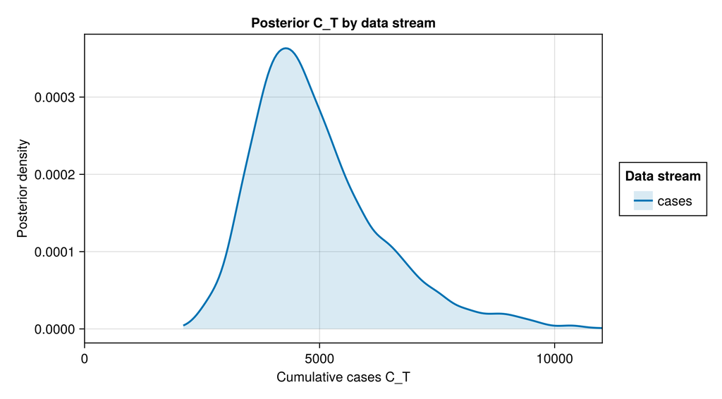

Reading these together:

- **Infections to date** is the headline count, : everyone infected by the data cut-off.
- **Cases (symptom onset to date)** is the smaller subset who have already developed symptoms by the cut-off, scaled by the share past the incubation period. The gap between the two is the recently infected still incubating, and it is this case count that lines up with McCabe et al. and the reported surveillance counts.

The cumulative infection count is set jointly by the doubling time , equivalently the growth rate , and the time since seeding . Read as a calendar date, places the start of sustained transmission at the report date minus days. The left panel below shows the posterior for that start date. The right panel shows the joint posterior, which is positively correlated: slower growth (larger ) needs a longer elapsed to reach the same observed counts.

**Outbreak start date and (τ, T) posterior**

julia

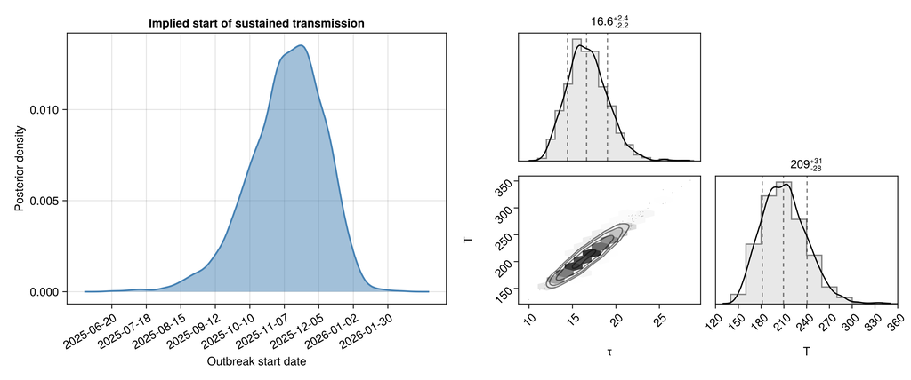

```julia
start_date_fig = plot_start_date_pair(chn_joint;
    as_of_date = obs.as_of_date);
```

The full posterior summary table reports equal-tailed 30%, 60% and 90% credible intervals on the key joint-fit parameters: growth rate , doubling count , days since seeding , CFR, the DRC and Uganda ascertainment fractions and , the pooling SD , the surveillance dispersion on both the sampled scale and the more familiar scale, the laboratory-pipeline parameters — onset-to-report delay shape and scale , , PCR sensitivity , specificity , the forwarded fraction , the severe-first share parameters , and , the non-BVD background rate , the per-suspected positivity and the per-test positivity — and cumulative cases .

**Joint posterior summary table**

julia

```julia
joint_summary = summary_table(chn_joint,
    [:r, :τ, :m, :T, :CFR, :p_drc, :p_uganda, :τ_logit,
        :inv_sqrt_k, :k, :α_rep, :θ_rep,
        :s_test, :spec_test, :λ_bg, :δ0, :decay_scale,
        :positivity, :p_positive, :q_cutoff, :q_baseline,
        :cumulative_infections, :cumulative_cases]; digits = 2);
```

23×7 DataFrame

| Row | Quantity String | Lower 90% Float64 | Lower 60% Float64 | Lower 30% Float64 | Upper 30% Float64 | Upper 60% Float64 | Upper 90% Float64 |
| --- | --- | --- | --- | --- | --- | --- | --- |
| 1 | r | 0.03 | 0.04 | 0.04 | 0.04 | 0.05 | 0.05 |
| 2 | τ | 13.18 | 14.69 | 15.63 | 17.41 | 18.53 | 20.71 |
| 3 | m | 12.01 | 12.27 | 12.42 | 12.7 | 12.89 | 13.26 |
| 4 | T | 166.5 | 184.31 | 196.0 | 218.64 | 234.1 | 263.72 |
| 5 | CFR | 0.17 | 0.23 | 0.26 | 0.32 | 0.37 | 0.45 |
| 6 | p_drc | 0.55 | 0.7 | 0.78 | 0.87 | 0.91 | 0.96 |
| 7 | p_uganda | 0.26 | 0.48 | 0.63 | 0.82 | 0.89 | 0.95 |
| 8 | τ_logit | 0.04 | 0.16 | 0.31 | 0.61 | 0.81 | 1.17 |
| 9 | inv_sqrt_k | 0.79 | 0.87 | 0.91 | 0.98 | 1.03 | 1.12 |
| 10 | k | 0.8 | 0.94 | 1.04 | 1.21 | 1.33 | 1.58 |
| 11 | α_rep | 0.3 | 0.75 | 1.09 | 1.85 | 2.26 | 3.05 |
| 12 | θ_rep | 1.11 | 2.21 | 2.86 | 4.13 | 4.85 | 6.1 |
| 13 | s_test | 0.72 | 0.75 | 0.78 | 0.81 | 0.83 | 0.88 |
| 14 | spec_test | 0.97 | 0.98 | 0.98 | 0.99 | 0.99 | 1.0 |
| 15 | λ_bg | 0.77 | 1.19 | 1.46 | 2.0 | 2.37 | 3.02 |
| 16 | δ0 | 0.06 | 0.25 | 0.45 | 0.89 | 1.2 | 1.82 |
| 17 | decay_scale | 0.2 | 0.9 | 2.31 | 6.91 | 10.81 | 18.01 |
| 18 | positivity | 0.74 | 0.8 | 0.83 | 0.87 | 0.89 | 0.93 |
| 19 | p_positive | 0.34 | 0.62 | 0.7 | 0.77 | 0.8 | 0.85 |
| 20 | q_cutoff | 0.42 | 0.78 | 0.91 | 0.99 | 1.0 | 1.0 |
| 21 | q_baseline | 0.82 | 0.86 | 0.88 | 0.91 | 0.93 | 0.96 |
| 22 | cumulative_infections | 4126.68 | 4944.02 | 5469.69 | 6653.36 | 7594.92 | 9843.03 |
| 23 | cumulative_cases | 3212.97 | 3845.12 | 4250.41 | 5175.77 | 5930.55 | 7664.87 |

The posterior pair plot shows the joint distribution of the key parameters, with the prior overlaid so the data's contribution to each marginal is visible.

**Posterior pair plot (prior overlaid)**

julia

```julia
posterior_pair_fig = plot_pair(chn_joint,
    [:r, :τ, :m, :cumulative_cases, :CFR, :α_rep, :inv_sqrt_k, :k,
        :p_drc, :p_uganda, :τ_logit];
    prior = prior_chn);
```

[figure not shown]

### Reporting process

The streams above all observe the same latent infections: infections become onsets after the incubation period, onsets enter the suspected line list after the onset-to-report delay, and the lab selects which of the received samples to confirm. The observed suspected count mixes an *accepted* (BVD-attributable) part and a non-BVD background (equation (18)). Only the total is observed. The accepted share is the per-suspected positivity in the summary table, so times the suspected total recovers the unobserved accepted-BVD count. This differs again from the lab-confirmed count, since only the tested samples enter the confirmed series.

**Laboratory-pipeline pair plot (prior overlaid)**

julia

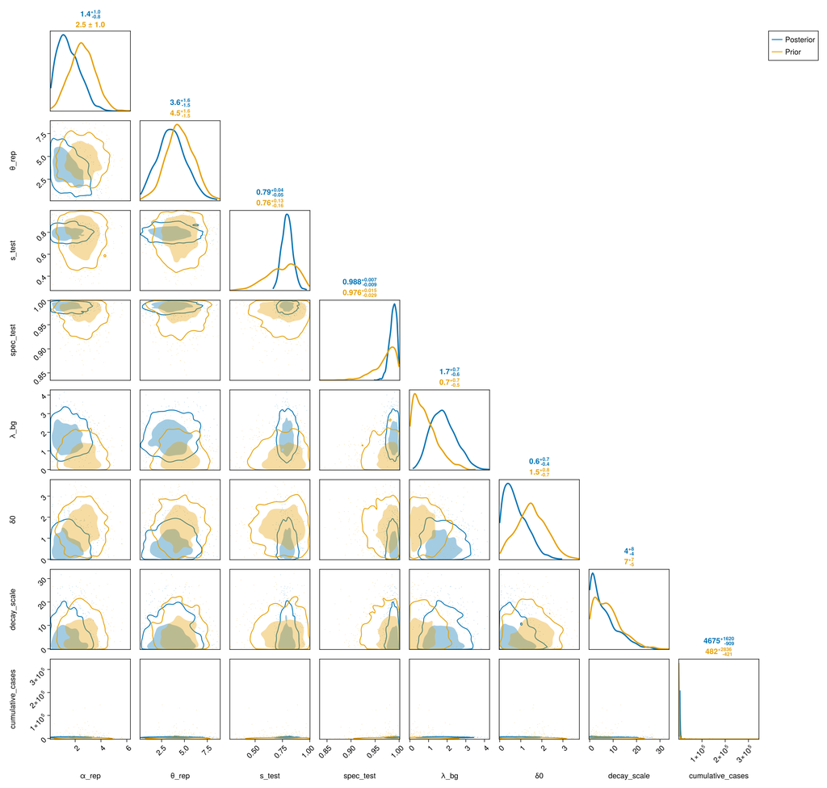

```julia
lab_pair_fig = plot_pair(chn_joint,
    [:α_rep, :θ_rep, :s_test, :spec_test,
        :λ_bg, :δ0, :decay_scale, :cumulative_cases];
    prior = prior_chn);
```

The DRC reporting fraction is the share of true cases that reach the reported suspected-case count; its prior centres near , so most cases are captured as suspected by the active case finding in the response. The large gap between true cases and the headline counts is instead at the laboratory: a case must be suspected, have a sample taken and analysed, and test positive to be confirmed, so only a small share of infections is ultimately laboratory-confirmed. The cumulative infection burden is therefore about one over that confirmation share times the confirmed total — the multiplier quoted in the summary. The pair plot above shows 's posterior against the prior.

The confirmed-case stream enters the joint fit per vintage, each vintage a Binomial on its observed analysed denominator (equation (21)). The joint therefore conditions on the positivity trajectory across the lab vintages, with the severe-first share carrying the fall in positivity from the early severe cluster to the broad-pool baseline (equation (23)). The samples-received series sets the forwarded fraction , and the per-vintage positivity sets the sensitivity and the share curve.

**Joint posterior predictive plot**

julia

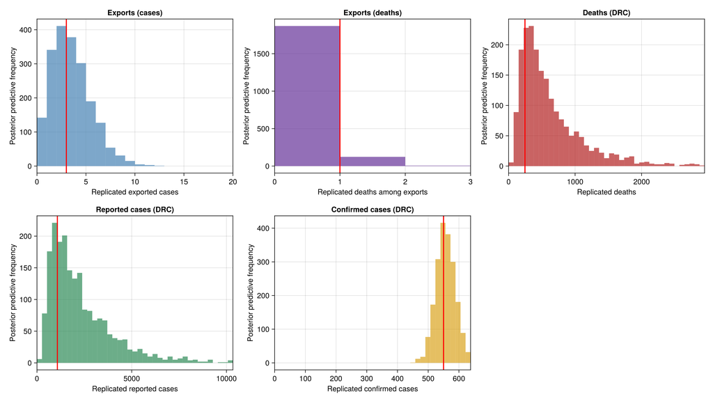

```julia
pp_args = joint_obs(obs; observe = false)
pp_joint = predict(
    bvd_joint(missing, pp_args.deaths, pp_args.reported,
        pp_args.export_deaths; pp_args.kw...,
        pre_start_deaths = missing,
        pre_detection_exports = missing,
        first_export_detection_delta = obs.first_export_detection_delta,
        report_onset_offset = report_onset_offset(obs.as_of_date),
        confirmed_q_random_effect = confirmed_q_re_model,
        genetic = genetic_seeding),
    chn_joint);
# Exports are now a dated per-day series (to the last reported import),
# so sum each draw's days for the cumulative-total posterior predictive,
# matching the observed total.
pp_exports = vec(sum.(pp_joint[@varname(exported_cases_daily)]));
# All DRC streams are now per-vintage increment vectors (deaths, reported,
# confirmed positives); sum each draw's bins for the cumulative-total
# posterior predictive. Export deaths are a per-day series summed the same
# way. The laboratory throughput (samples received and analysed) is a
# conditioned input to the queue, not a generated quantity, so it has no
# posterior-predictive panel here; the confirmed positives it drives do.
pp_deaths = vec(sum.(pp_joint[@varname(total_deaths)]));
pp_cases = vec(sum.(pp_joint[@varname(reported_cases)]));
pp_confirmed = vec(sum.(pp_joint[@varname(confirmed_cases)]));
pp_exports_deaths = vec(sum.(pp_joint[@varname(export_deaths_daily)]));

joint_ppc_fig = plot_posterior_predictive(
    pp_exports, pp_deaths,
    obs.exported_cases, obs.total_deaths;
    pp_cases = pp_cases,
    obs_cases = obs.reported_cases,
    pp_exports_deaths = pp_exports_deaths,
    obs_exports_deaths = obs.exports_deaths,
    pp_confirmed = pp_confirmed,
    obs_confirmed = obs.confirmed_cases);
```

### Conditional one-step-ahead predictive across the sitrep series

The panels above collapse each DRC stream to a single total. Because the suspected-case and death streams are fitted per vintage, we can also check the fit one sitrep at a time. For each vintage we condition on what was actually observed at the previous sitrep and predict only the new between-vintage increment, with , defined in the observation model. Each step carries the full posterior uncertainty of the new increment while conditioning on the observed previous cumulative, so the diagnostic isolates the model's per-step increment prediction and its errors do not compound across the series. The observed cumulative counts are overlaid as points. If the fit is reasonable each point sits inside the predictive ribbon for its vintage.

**Per-vintage conditional one-step-ahead predictive**

julia

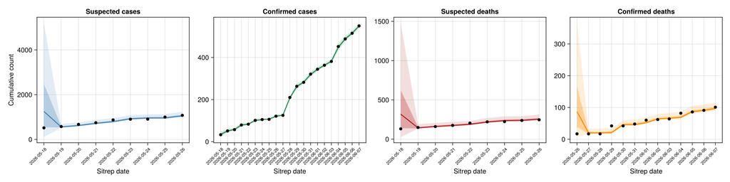

```julia
# Every confirmed-case and confirmed-death vintage is fitted as a
# between-vintage increment, so the replicate vectors align one-to-one
# with the full confirmed histories (cumulative observed per vintage).
vintage_ppc_fig = plot_vintage_conditional_ppc([
    (; title = "Suspected cases",
        dates = obs.reported_case_history.dates,
        replicates = collect(pp_joint[@varname(reported_cases)]),
        observed = obs.reported_case_history.values, colour = :steelblue),
    (; title = "Confirmed cases",
        dates = obs.confirmed_case_history.dates,
        replicates = collect(pp_joint[@varname(confirmed_cases)]),
        observed = obs.confirmed_case_history.values, colour = :seagreen),
    (; title = "Suspected deaths",
        dates = obs.death_history.dates,
        replicates = collect(pp_joint[@varname(total_deaths)]),
        observed = obs.death_history.values, colour = :firebrick),
    (; title = "Confirmed deaths",
        dates = obs.confirmed_death_history.dates,
        replicates = collect(pp_joint[@varname(confirmed_deaths)]),
        observed = obs.confirmed_death_history.values,
        colour = :darkorange)]);
```

### Counterfactual: lower bound under no further transmission

The lower bound on cumulative deaths if transmission stopped at the report date: still-expected and projected-total deaths per draw.

**Project no-onward deaths and summarise**

julia

```julia
no_onward = predict_no_onward_deaths(chn_joint; obs_deaths = obs.total_deaths);

no_onward_table = streams_table(
    "no-onward total" => no_onward.total_projected;
    digits = 0);
```

1×7 DataFrame

| Row | Stream String | Lower 90% Float64 | Lower 60% Float64 | Lower 30% Float64 | Upper 30% Float64 | Upper 60% Float64 | Upper 90% Float64 |
| --- | --- | --- | --- | --- | --- | --- | --- |
| 1 | no-onward total | 368.0 | 486.0 | 575.0 | 750.0 | 883.0 | 1164.0 |

Two panels. On the left, the *still expected* deaths , future deaths in cases already infected by net of those already observed. On the right, the *projected total* with the observed death count marked as a dashed black rule.

**No-onward projected-deaths plot**

julia

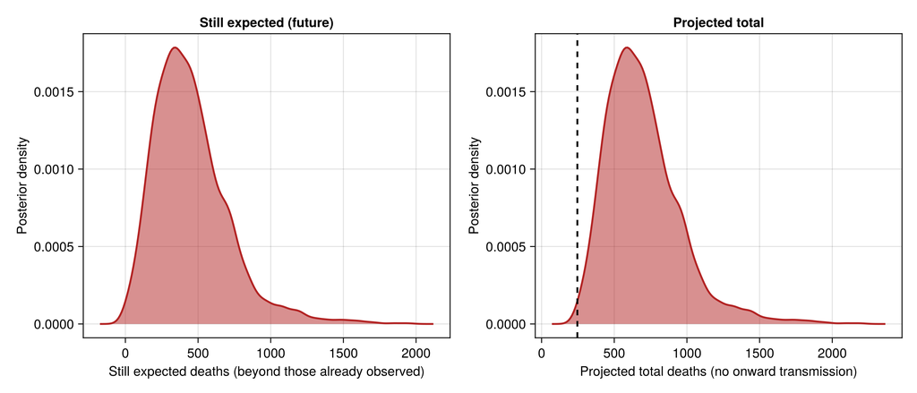

```julia
no_onward_fig = plot_no_onward_deaths(no_onward; obs_deaths = obs.total_deaths);
```

### Counterfactual-year committed totals

The committed toll over the coming year under no onward transmission. Infections are held flat at the current outbreak size after the cut-off, and the already-infected pool continues to die and be confirmed over a one-year horizon. Four committed totals per draw: infections (the current outbreak size, flat), true BVD deaths (, since over a year essentially every infection contributes its delayed death), and the laboratory-confirmed cases and confirmed deaths the lab will record as it drains the committed backlog.

**Project the committed counterfactual-year totals**

julia

```julia
committed = predict_committed(chn_joint;
    obs_confirmed = obs.confirmed_cases,
    obs_confirmed_deaths = obs.confirmed_deaths,
    obs_analysed = obs.cumulative_tests_analysed,
    horizon_days = 365);

committed_table = streams_table(
    "committed infections" => committed.infections,
    "committed BVD deaths" => committed.bvd_deaths,
    "committed confirmed cases" => committed.confirmed_cases,
    "committed confirmed deaths" => committed.confirmed_deaths;
    digits = 0);
```

4×7 DataFrame

| Row | Stream String | Lower 90% Float64 | Lower 60% Float64 | Lower 30% Float64 | Upper 30% Float64 | Upper 60% Float64 | Upper 90% Float64 |
| --- | --- | --- | --- | --- | --- | --- | --- |
| 1 | committed infections | 4127.0 | 4944.0 | 5470.0 | 6653.0 | 7595.0 | 9843.0 |
| 2 | committed BVD deaths | 1110.0 | 1397.0 | 1576.0 | 1948.0 | 2238.0 | 2782.0 |
| 3 | committed confirmed cases | 2237.0 | 2614.0 | 2852.0 | 3314.0 | 3620.0 | 4456.0 |
| 4 | committed confirmed deaths | 134.0 | 159.0 | 177.0 | 212.0 | 241.0 | 306.0 |

The four committed-total panels:

**Committed counterfactual-year plot**

julia

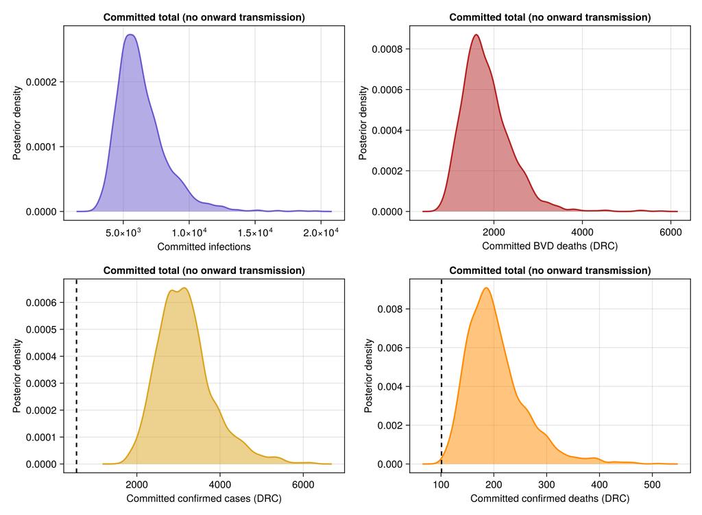

```julia
committed_fig = plot_committed(committed;
    obs_confirmed = obs.confirmed_cases,
    obs_confirmed_deaths = obs.confirmed_deaths);
```

### One-week-ahead forecast

The seven-day no-change projection of the four trusted quantities: the new counts expected over the coming week for infections, true BVD deaths, laboratory-confirmed cases and laboratory-confirmed deaths. The untrusted suspected/reported cases, suspected deaths and tests-analysed streams are dropped. Exports are also dropped from this projection. Cross-border travel is unlikely to be continuing at its baseline rate, so the forward travel rate the export forecast relies on no longer holds.

**Generate the one-week-ahead forecast**

julia

```julia
forecast = forecast_reported(chn_joint;
    horizon = 7,
    daily_travellers = ITURI_DAILY_TRAVEL,
    source_population = ITURI_POPULATION,
    obs_confirmed = obs.confirmed_cases,
    obs_confirmed_deaths = obs.confirmed_deaths,
    obs_analysed = obs.cumulative_tests_analysed,
    forecast_exports = false,
    report_onset_offset = report_onset_offset(obs.as_of_date));
forecast_summary = forecast_table(forecast);
```

4×7 DataFrame

| Row | Quantity String | Lower 90% Float64 | Lower 60% Float64 | Lower 30% Float64 | Upper 30% Float64 | Upper 60% Float64 | Upper 90% Float64 |
| --- | --- | --- | --- | --- | --- | --- | --- |
| 1 | New infections | 1269.0 | 1613.0 | 1841.0 | 2338.0 | 2708.0 | 3701.0 |
| 2 | New BVD deaths (DRC) | 21.0 | 85.0 | 152.0 | 350.0 | 524.0 | 942.0 |
| 3 | New confirmed cases (DRC) | 14.0 | 60.0 | 114.0 | 263.0 | 406.0 | 789.0 |
| 4 | New confirmed deaths (DRC) | 4.0 | 16.0 | 29.0 | 69.0 | 106.0 | 197.0 |

New counts expected over the coming week, by quantity:

**One-week-ahead forecast plot**

julia

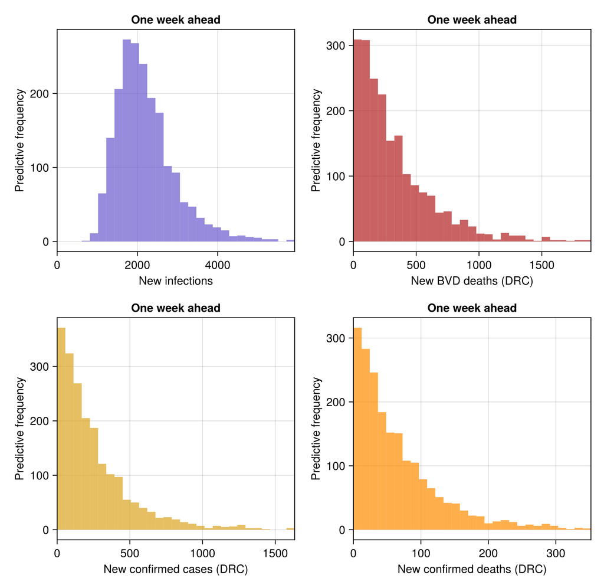

```julia
forecast_fig = plot_forecast(forecast);
```